# 6 Importing and exporting data

Here, we will often use {tidyverse} packages. To do so, we need to load these packages in R using

```r
library(tidyverse)
library(readr)
library(readxl)
```

## 6.1 Reading file names and folders

Before we import data, let’s first see how you can determine which files are stored in a directory. Base R includes the function `list.files()`. This function allows you to see which files are included in a given directory or folder.

```r
list.files(path = ".",
           pattern = NULL,
           all.files = FALSE,
           full.names = FALSE,
           recursive = FALSE,
           ignore.case = FALSE,
           include.dirs = FALSE,
           no.. = FALSE)
```

The `path = "."` refers to the folder. With a project, you can use the {here} package to set the folder relative to the root folders of the project. This also allows you to define a folder using `here::here()`:

```r
folder <- here::here("data", "raw")
```

In this case, the object `folder` will include the name of the folder relative to the project’s root. In other words, it will include `c:> ... > root > data > raw`. You can verify this using the values part in the environment pane.

Using only this argument, `list.files()` returns all files in the `... > root > data > raw` folder. The return structure is a vector. In this case, there are three folders (`ameco_csv`, `ameco_txt` and `ameco_xlsx`) and multiple files: (multiple) `.csv` and `.xlsx` files and one `.R` file. To store these in a separate object, you assign the result of the `list.files()` function to an object, e.g.

```r
files_data_raw <- list.files(path = folder)
files_data_raw
```

```
 [1] "ameco_csv"              "ameco_txt"              "ameco_xlsx"
 [4] "AMECO1.CSV"             "AMS_Price_2026_03.csv"  "AMS_Price_2026_03.xlsx"
 [7] "AMS_Units_2026_03.csv"  "AMS_Units_2026_03.xlsx" "BRU_Price_2026_03.csv"
[10] "BRU_Price_2026_03.xlsx" "BRU_Units_2026_03.csv"  "BRU_Units_2026_03.xlsx"
[13] "Glints_Daan.R"          "LON_Price_2026_03.csv"  "LON_Price_2026_03.xlsx"
[16] "LON_Units_2026_03.csv"  "LON_Units_2026_03.xlsx" "MAD_Price_2026_03.csv"
[19] "MAD_Price_2026_03.xlsx" "MAD_Units_2026_03.csv"  "MAD_Units_2026_03.xlsx"
[22] "PAR_Price_2026_03.csv"  "PAR_Price_2026_03.xlsx" "PAR_Units_2026_03.csv"
[25] "PAR_Units_2026_03.xlsx" "Price_2026_03.xlsx"     "Units_2026_03.xlsx"
```

Adding a `pattern =` as an argument in `list.files()` allows you to narrow the result of the function to files where a pattern occurs. Here, you can use e.g. regular expressions. For instance suppose that you only want a list of `.csv` files whose name includes “AMS”. To select only those files you can use the regular expression `"AMS\\S+.csv$"`. This pattern will match all file names whose name starts with “AMS”, followed by one or more non whitespace characters `\\S+` and end with `.csv` (`.csv$)`. Adding this pattern to `list.files()` and assigning the result to a vector `files_data_csv`:

```r
files_data_csv <- list.files(path = folder,
                             pattern = "AMS\\S+.csv$")
files_data_csv
```

```
[1] "AMS_Price_2026_03.csv" "AMS_Units_2026_03.csv"
```

The other arguments in `list.files()` refer which files that are shown or how they are shown. With `all.names = FALSE`, only visible files are shown, invisible files are not. Changing this from `FALSE` into `TRUE` would change this. To include the directory path in the file name, you can change the `full.names = FALSE` to `TRUE`. You will want to change this option if you want to import multiple files in your session. If you add this option, R stores all file names including the directory or folder where the file is located. Here, R starts from the root folder `c:\` and not from the project’s root. If the file name includes variables that you would want to include in your analysis. Suppose for instance that the file does not include a column “year” but only references the month. If the filename includes a reference to the year, you can extract that reference and use it as a value for the variable “year”. If the data folder includes subfolders, adding `recursive = TRUE` will return all files in all subfolders. To show the subfolders in the folder, you can use `include.dirs = TRUE`. The `ignore.case = FALSE` argument by default uses case sensitive patterns.

R includes two special cases of `list.files()`: `dir()` and `list.dirs()`. The former is an alias for `list.files()`. In other words, you can also use `dir()` and read in the files you folder. For instance,

```r
dir(path = folder, pattern = "AMS\\S+.csv$")
```

```
[1] "AMS_Price_2026_03.csv" "AMS_Units_2026_03.csv"
```

show the same result as `list.files()`. The second function, `list.dirs()` returns the same output as `list.files(all.files = TRUE)` and if `recursive = TRUE` also returns the full path name.

Using the a vector such as `files_data_raw` or a character such as `files_data_csv`, you can now import these files.

## 6.2 Reading rectangular tables

Rectangular tables are datasets where each column has the same number of rows. Columns are separated by a delimiter, for instance a comma, a tab or a white space. The {readr} package includes a number of functions that allows you to import these types of files. Excel or googlesheet files store data in a different way. To import data from an excel spreadsheet, {readxl} includes three functions to do so. For googlesheets, the package is {googlesheets4}. {haven} allows you to read STATA, SAS and SPSS files. Usually, these packages also allow you to write files. The {rio} package, also referred to as the Swiss army knife to import data, calls the functions in these packages to import the data. Doing so, you can use {rio} as a substitute most other functions: given the type of data, {rio} calls the appropriate function and imports the data. You can also use {rio} to write files in these formats.

### 6.2.1 Delimited files

Rectangular datasets are stored in rows and columns. Between the columns, there has to be a delimiter to indicate where one column ends and another column starts. A delimited file (opened in excel) looks like the one in Figure 6.1

Figure 6.1: A comma delimited file

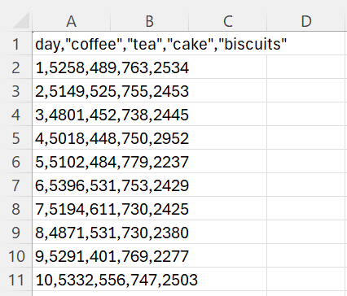

Here, you can see that the first row includes the column headers or variable names. These are separated by comma’s: “day”, “coffee”, “tea” … In the second row, you have the values. These too are separated by comma’s: 1,5258,489,763,2534. In other words, this is a comma delimited file. If you import the data in R or in any other package, that package will interpret these comma’s as indicators that a new column starts. Doing so, packages will create columns “day”, “coffee”, … and fill these columns with the values 1 (day), 5258 (coffee), …. Here, this file used a comma to indicate a new column, other separators include a space, a tab, a semi-colon, … .

{readr} includes various functions to read these delimited files. The most general function is `read_delim()`. If a file is known to be comma delimited, {readr} includes `read_csv()` and `read_csv2()`. For tab delimited files you can use {readr}’s `read_tsv()`. In H. Wickham, Hester, and Bryan (2024), you can find all information with respect to these functions. You can also download the [cheatsheet](https://raw.githubusercontent.com/rstudio/cheatsheets/main/data-import.pdf) where the first page includes the {readr} functions. Here, we’ll start with the general case and then discuss the functions to import a comma delimited and a tab delimited file as two special cases. To import deliminted files, “base R” includes `read.delim()`, `read.csv()` or `read.tsv()`. Note the dot in the function name as opposed to the underscore for {readr} functions. Here, we will always use {readr} functions. In other words, you always need the `_`. {readr} returns a tibble while base R’s function return a data frame.

If you ran `library(tidyverse)` at the start of this chapter, you don’t have to reload the package. If you didn’t run the `library` function, you can load {readr} using

```r
library(readr)
```

All these function return a tibble.

#### 6.2.1.1 General case: `read_delim()` and `write_delim()`

{readr}’s `read_delim()` is a function that allows you to read and import most delimited files, whether they are comma, tab, semi-colon or use any other symbol to delimit columns. Because the function is widely applicable, it includes many optional arguments. Here is the full function, including the default values:

```r
read_delim(
  file,
  delim = NULL,
  quote = "\"",
  escape_backslash = FALSE,
  escape_double = TRUE,
  col_names = TRUE,
  col_types = NULL,
  col_select = NULL,
  id = NULL,
  locale = default_locale(),
  na = c("", "NA"),
  quoted_na = TRUE,
  comment = "",
  trim_ws = FALSE,
  skip = 0,
  n_max = Inf,
  guess_max = min(1000, n_max),
  name_repair = "unique",
  num_threads = readr_threads(),
  progress = show_progress(),
  show_col_types = should_show_types(),
  skip_empty_rows = TRUE,
  lazy = should_read_lazy()
)
```

The first argument, `file` includes the path to the file. Zipped files (ending in `.zip` or `.gz` for instance) are automatically uncompressed. If you add multiple files and these files all include the same columns, R will read them in at once and stack them. If you read them as individual files, you would have to do this last operation yourself using e.g. `rbind()`. Using `cbind()`, you can add two data sets by column. We’ll cover those options more in depth. The `file` argument can also include a web address. If that is the case and R detects `https://`, `http://`, `ftps://` or `ftp://` R will download the file.

The `delim` argument shows the character used to separate the various columns. Although any symbol can be used, most often used delimiters are a comma `,` a semi-colon `;` a space `" "`, a tab `\\t` or a vertical bar `|`. Note that R uses the regular expression for a tab: `\\t`.

Some files include character variables. With respect to those, the question is how they are shown. In other words, how does R know that “2” is a string? Or how does R now that “Sales, november” refers to one value and shouldn’t be split up in two in a comma delimited file? The `quote` argument allows you the specify which character is used to quote strings. By default, R uses `"`. The `escape_double = TRUE` argument assumes that a file escapes a quote by doubling it. Recall that an escape symbol “escapes” the normal meaning of another symbol. For instance, the “\\d” refers to any digit and the “\\” is used to escape both the normal meaning of the “\” and the “d”. In `read_delim()` the default is `escape_double = TRUE`. In other words, the quote symbol (e.g. ““) is doubled to escape it. If that is the case `""""` will escape the usual interpretation for a quote symbol. In `""""`, the first `""` are telling R not to interpret the last `""` as a quote symbol. If the quote symbol is escaped, R will read” as part of the string. For instance in the character value “The color was”blue” “, without an escape on the quote symbol, R wouldn’t know how to interpret”blue”. To avoid this: ” The color was ““blue”” ” shows that the quotes around “blue” are real quotes and not quote symbols. More in general, the `escape_backslash = FALSE` argument allows you to specify if the backslash is used as an escape symbol. If that is the case “\\d”” will be read not as a “d” but as a “digit”. With respect to white spaces, by default R will not remove trailing or leading whitespaces from each field. These white spaces can also refer to tabs. Changing the default `trim_ws` from `FALSE` to `TRUE`, will change that behavior.

The three `col_` arguments allow you to specify if the first row includes column names. By default, this is what R assumes. If `FALSE`, R assumes no column names in the first row. This options also allows you to specify the names of the columns in a vector using `c("col_name_1", ...)`. If you want to rename columns, you can add the new names in this `c()` function. Do do so, you include the new name of the column whose name you want to change first as well as the current name with an `=` separating the new and current name. For instance, suppose you want to change the variable name from `sales2024` to `sales_2024`, you can include that in using `c(sales_2024 = sales 2024)`. Doing so, R will change the column name.

Using `name_repair()`, you can check the names in the dataset. By default, R will check if the names are unique. Other options include “minimal” where R checks only if names exist and “universal” which checks the uniqueness of the names and also adjusts the way they are written, e.g. removing white spaces and replacing them with a dot, … .

You can specify the type of every column in `col_types`. The default option, `NULL`, implies that R will try to guess the column types. You can add the column types using the function `cols()` or using a list to specify the column types. To fix the column types, you can use a full column type or use an abbreviation. Column types are:

- col_logical() or “l”
- col_integer() or “i”
- col_double() or “d”
- col_character() or “c”
- col_factor(levels, ordered) or “f”
- col_date(format = ) or “D” for the format in local date specification
- col_time(format = ) or “t” for the format in local time specification
- col_datatime(format = ) or “T” for ISO8601
- col_number or “n” for numbers containing a grouping mark
- col_skip() or “_” or “-” for don’t import this column
- col_guess() or “?” for guess best type.

For instance if the dataset includes three columns, one integer, one double and one date, you would use `col_types = list(col_integer(), col_double(), col_date(format = "%Y-%m-%d))`. As an alternative, you can use `cols(col1 = col_integer(), col2 = col_double, ...)`. Using the short cuts: this code is shorter: `cols(col1 = "i", col2 = "d", ...)`. Note that for columns that are not included in the `cols()` function, R will guess the type. If you add `skip`, R will not import that column. In other words, `col_types = list(col_skip(), col_double(), col_data(format : %Y-%m-%d))` in the previous example, wouldn’t import the first integer column. There are a couple of other ways to shorten this code. For instance, suppose that you have a large dataset where almost all columns are numeric, except couple or a small number columns that are not. For instance, you have a column with the name `col_char` which is a character variable while all others are numeric. Using `cols(.default = col_double, col_char = col_character(), ...)` you can avoid that you have to include all columns in the `cols()` function. Here, you tell R that all columns are numeric, except `col_char` which is included as a character column. In other words, you only include the columns by name whose type deviates from the default numeric and add `.default = col_double` to indicate that all other columns are numeric (or any other type). Using `cols()` you can further specify if you only want to read columns with a specific type. Note that you can change the type of the data after importing using e.g. `as.numeric()`, `as.factor()` or `as.character()`.

With the `show_col_types` you can ask R to shows the column types after importing the file. By default, this is what R will do. This is usually what you want: after reading the data, it allows you to quickly inspect the data and see if the columns types have the expected type. If don’t want this, you can include `FALSE`. Doing so, R will not show column types after reading.

The argument `locale()` allows you determine the default way to store numeric variables or dates and times for a specific location: for instance, what symbol is used for a decimal sign, how are days, times and months shown, … . The default value is `default_locale()`. You can check that default using

```r
readr::default_locale()
```

```
<locale>
Numbers:  123,456.78
Formats:  %AD / %AT
Timezone: UTC
Encoding: UTF-8
<date_names>
Days:   Sunday (Sun), Monday (Mon), Tuesday (Tue), Wednesday (Wed), Thursday
        (Thu), Friday (Fri), Saturday (Sat)
Months: January (Jan), February (Feb), March (Mar), April (Apr), May (May),
        June (Jun), July (Jul), August (Aug), September (Sep), October
        (Oct), November (Nov), December (Dec)
AM/PM:  AM/PM
```

The output shows that the default here uses a dot as a decimal sign and a comma as a grouping sign in numbers. The date and time formats will be shown using the familiar year-month-date and time as hour-minute-second. If you want to change any of these values, you can set the locale using

```r
locale(
  date_names = "en",
  date_format = "%AD",
  time_format = "%AT",
  decimal_mark = ".",
  grouping_mark = ",",
  tz = "UTC",
  encoding = "UTF-8",
  asciify = FALSE
)
```

For instance, to use a comma for a decimal mark, you can change the `decimal_mark = "."` in `decimal_mark = ","` and e.g. the grouping mark in `grouping = "."`. Doing so, R will write numbers as 123.456,789 and not 132,456.789.

With `col_select` you can select the columns to import. You do so either referring to those columns by their name (in the first row) or by column number in a vector using `c().` In addition, you can use helper functions such as `starts_with()` to import only those columns that start with a prefix, `ends_with()` to import only those columns that end with a suffix, `contains()` to import columns whose name includes a string, `matches()` to import columns based on a regular expression or matches a numerical range using `num_range()`. Using `where()` you can include a logical condition to select the columns, for instance `where(is.numeric)`. As an example, to import all columns that start with `sales` and end with `2024` you would use `col_select = c(starts_with("sales") & ends_with("2024"))`. Note that you can use boolean operators such as `!`, `|`, … For example `!starts_with("sales")` would import all columns except those whose name starts with “sales”. Note that you can also remove columns after importing. If you import the full dataset, you can remove columns as part of your data wrangling processes.

In addition to selecting the column to read, you can also tell R to skip lines. The first argument to do so is `skip = n`. If `n` is equal to one or any other integer, R will ignore the first `n` lines in the file. This might be necessary if the file include a line with e.g. additional information on the data in the file. If the file includes comments, you can include the comment symbol in `comment = ""`. Doing so, R will also ignore these lines if it imports a file. By default, R will skip empty rows. You can change that by changing the default `FALSE` in `TRUE` in the `skip_empty_rows` argument.

If you import multiple files, changing the default `id = NULL` into e.g. `id = name` will create an additional column `name` including file name (with full location details). For instance, importing data from two files, `sales_2024.csv` and `sales_2025.csv` will add a column with the value `sales_2024.csv` (including full reference to the folder) for all observations from the file with the same name and the value `sales_2025.csv` for the observation from the file `sales_2025`. This is very helpful if the name of the files include information on the data that is stored in those files. Suppose for instance that none of these two files include a reference to the year or to sales, using the name of the file will allow you to identify these values. Doing this after importing the files would require additional coding that is sensitive to mistakes. For instance, if the first 20 observations are from file 1 and the second 20 from file 2, you can add a column and include the value `file1` for the first 20 observations and `file2` for the last 20. However, here you need to determine the number of observations for each file. Doing so manually is usually very sensitive to mistakes. In other words, adding the lines while importing is often the saver solution.

The `na = c("", "NA")` changes an empty value or an “NA” character in a missing value. If in addition to those two, your dataset also includes, e.g. “N\A” as a missing value or “-999999”, you can add these in the `c()` function. R will treat these values as missing values: `c("", "NA", "N\A", "-999999")`.

The argument `guess_max = min(1000, n_max)` shows that R will use the first 1000 observations to guess the type of a variable. If there aren’t 1000 observations in your dataset, R will use all (`n_max`). Usually, this is sufficient. However, there are instances where the original files were saved with all NA values for one column at the top. Suppose that you have a dataset with 5000 observations and that there are 1200 missing observations for one of variables in the dataset’s variables. All other values are numeric. Suppose also that the person who saved the file, first ordered it so that all missing values for the variable appear at the top. In this case R will guess the type from first 1000 observations. If you import this file and you scan both the upper as well as bottom observations, you’ll notice that these at the bottom have the wrong type. Re-importing after increasing the 1000 in `guess_max = min(1000, n_max)` to e.g. 1250, will solve that issue.

To see how this function words, let’s try to import a couple of files. To illustrate this and other function, I’ll use the European Commission’s [AMECO dataset](https://economy-finance.ec.europa.eu/economic-research-and-databases/economic-databases/ameco-database_en). You can find a description of all variables in this dataset on the [AMECO pages].

You can access this dataset in multiple ways. First, the EU Commission allows you to download all datafiles in one zip file. The format of these files is `txt`, `csv` or `xlsx`. Second, you can access this data set online. In the `data > raw` folder of your project, you should add `ameco_csv`, `ameco_txt` and `ameco_xlsx` including their files. These files include all files in csv, txt and xlsx format. These files are always named `AMECOxx` with `xx` a number referring to the chapter fo the datasets. In `ameco_txt` there are two files with another name, `AMECO1_colheader` and `AMECO1_skiplines`. The `ameco_csv` folder includes `ameco1_part1_csv` and `ameco1_part2.csv`. I created these files.

We will start with the `txt` files. If you open the file, e.g. `AMECO1.TXT`, a quick inspection shows that the files are delimited with a semicolon `;`, that the decimal sign is a dot `.` and that the files include column names. Using these values in `read_delim()` and assigning this dataset to `df_pop` (the first chapter of AMECO’s database includes population statistics):

```r
df_pop <- read_delim(
  file = here::here("data", "raw", "ameco_txt", "AMECO1.TXT"),
  delim = ";",
  col_names = TRUE
)
```

```r
df_pop <- read_delim(
  file = here::here("data", "raw", "ameco_txt", "AMECO1.TXT"),
  delim = ";",
  col_names = TRUE,
  trim_ws = TRUE,
  col_select = c(1:72)
  )
```

Let’s add another issue. The file `AMECO1_colheader.TXT` does not include a column header. Here, you have a couple of alternatives. First you can read the file without the column names and add them later. Second, you can add the column names as an argument in the `read_delim()` function. Let’s show the first case. Here we add `col_names = FALSE` as an argument:

```r
df_pop <- read_delim(
  file = here::here("data", "raw", "ameco_txt", "AMECO1_colheader.TXT"),
  delim = ";",
  col_names = FALSE,
  trim_ws = TRUE,
  col_select = c(1:72)
 )
```

R didn’t read the column names and replaced them by the “names” X1, X2, … X72. In other words, if the files don’t include a column header, R will add its own names using X1, … You can add names to this unnamed data frame using e.g.

```r
names(df_pop) <- c("code", "country", "sub_chapter", "title", "unit", 1960:2026)
```

The data set is now named.

As an alternative you include these names as an argument in `read_delim()`:

```r
df_pop <- read_delim(
  file = here::here("data", "raw", "ameco_txt", "AMECO1_colheader.TXT"),
  delim = ";",
  col_names = c("code", "country", "sub_chapter", "title", "unit", 1960:2026),
  trim_ws = TRUE,
  col_select = c(1:72)
 )
```

R now replaces the column headers by the names you include in `col_names = c(...)`.

The file `AMECO1_skiplines.TXT` includes two lines at the top “# AMECO Population data” and “# AMECO EU Commission”. On the third line, the file includes column names. To skip these first two lines, you can add `skip = 2`. With `col_names = TRUE`, R will not import the first two lines and use the third line for read the names of the columns:

```r
df_pop <- read_delim(
  file = here::here("data", "raw", "ameco_txt", "AMECO1_skiplines.TXT"),
  delim = ";",
  col_names = TRUE,
  trim_ws = TRUE,
  skip = 2,
  col_select = c(1:72)
 )
```

Lines 1 and 2 both started with a “#”. As an alternative to skip, you can also include `comment = "#"`. R doesn’t import lines starting with the symbol after the `comment = ""` argument. Using this approach to skip the first two lines (or any other line where the first character is a hash tag):

```r
df_pop <- read_delim(
  file = here::here("data", "raw", "ameco_txt", "AMECO1_skiplines.TXT"),
  delim = ";",
  col_names = TRUE,
  trim_ws = TRUE,
  comment = "#",
  col_select = c(1:72)
 )
```

Using the tidyselect helpers `starts_with()`, `ends_with()`, `contains()`, `matches()` or `num_range()` witht the `col_select` argument, you can select columns from the file whose name starts with, ends with, contains an exact pattern or, using `matches()` matches a regular expression and includes a numeric range. For the latter option, the numeric range can include a prefix. For all options, these helper function include the `ignore.case = TRUE` argument and allows you to add a vector with variables names in the `var =` argument. For instance, to select the columns whose name

- starts with “C”:

```r
df_inc <- read_delim(
  file = here::here("data", "raw", "ameco_txt", "AMECO15.TXT"),
  delim = ";",
  col_names = TRUE,
  col_select = starts_with("C", ignore.case = FALSE)
  )
```

- ends with “0”

```r
df_inc <- read_delim(
  file = here::here("data", "raw", "ameco_txt", "AMECO15.TXT"),
  delim = ";",
  col_names = TRUE,
  col_select = ends_with("0")
)
```

- contains the years 2000 to 2009 (using ´paste0()`):

```r
df_inc <- read_delim(
  file = here::here("data", "raw", "ameco_txt", "AMECO15.TXT"),
  delim = ";",
  col_names = TRUE,
  col_select = contains(paste0("200", 0:9))
)
```

- matches a regular expression matching only years ending with 2

```r
df_inc <- read_delim(
  file = here::here("data", "raw", "ameco_txt", "AMECO15.TXT"),
  delim = ";",
  col_names = TRUE,
  col_select = matches("\\d{3}2")
)
```

- includes the numeric range 2000 to 2025 (without a prefix)

```r
df_inc <- read_delim(
  file = here::here("data", "raw", "ameco_txt", "AMECO15.TXT"),
  delim = ";",
  col_names = TRUE,
  col_select = num_range(prefix = NULL, range = 2000:2025)
)
```

- include any of the columns 2000, 2001, 2002, 2010, 2011, 2012

```r
df_inc <- read_delim(
  file = here::here("data", "raw", "ameco_txt", "AMECO15.TXT"),
  delim = ";",
  col_names = TRUE,
  col_select = any_of(c("2000", "2001", "2002", "2010", "2011", "2012"))
)
```

- include all of the columns 2000, 2001, 2002, 2010, 2011, 2012

```r
df_inc <- read_delim(
  file = here::here("data", "raw", "ameco_txt", "AMECO15.TXT"),
  delim = ";",
  col_names = TRUE,
  col_select = all_of(c("2000", "2001", "2002", "2010", "2011", "2012"))
)
```

Where `any_of` will import all the columns that are present in the file `all_of` only imports the file if all of the columns are in the file. For instance, 2035 is not a year in the AMECO dataset. Importing columns 2000, 2001 and 2035 using `any_of` will import the columns 2000 and 2001

```r
df_inc <- read_delim(
  file = here::here("data", "raw", "ameco_txt", "AMECO15.TXT"),
  delim = ";",
  col_names = TRUE,
  col_select = any_of(c("2000", "2001", "2035"))
)
```

while `all_of` will fail to import the data:

```r
df_inc <- read_delim(
  file = here::here("data", "raw", "ameco_txt", "AMECO15.TXT"),
  delim = ";",
  col_names = TRUE,
  col_select = all_of(c("2000", "2001", "2035"))
)
```

```
Error:
ℹ In argument: `all_of(c("2000", "2001", "2035"))`.
Caused by error in `all_of()`:
! Can't subset elements that don't exist.
✖ Element `2035` doesn't exist.
```

**CautionYour turn**

Using `read.delim()` import the file `AMECO6.TXT` from the directory `data > raw > ameco_txt`. Check if all variables have the expected type. If this is not the case, solve that issue. Store this dataset in a tibble `df_gdp`

```r
df_gdp <- read_delim(
  file = here::here("data", "raw", "ameco_txt", "AMECO6.TXT"),
  delim = ";",
  col_names = TRUE,
  trim_ws = TRUE,
  col_select = c(1:72)
  )
```

Using the output: how many lines did you import?

Suppose that you would like to add your own names to the file `AMECO13.TXT`:

```r
c("code","country", "sub_chapter", "variable", "unit", paste("year", 1960:2026, sep = "_"))
```

```
 [1] "code"        "country"     "sub_chapter" "variable"    "unit"
 [6] "year_1960"   "year_1961"   "year_1962"   "year_1963"   "year_1964"
[11] "year_1965"   "year_1966"   "year_1967"   "year_1968"   "year_1969"
[16] "year_1970"   "year_1971"   "year_1972"   "year_1973"   "year_1974"
[21] "year_1975"   "year_1976"   "year_1977"   "year_1978"   "year_1979"
[26] "year_1980"   "year_1981"   "year_1982"   "year_1983"   "year_1984"
[31] "year_1985"   "year_1986"   "year_1987"   "year_1988"   "year_1989"
[36] "year_1990"   "year_1991"   "year_1992"   "year_1993"   "year_1994"
[41] "year_1995"   "year_1996"   "year_1997"   "year_1998"   "year_1999"
[46] "year_2000"   "year_2001"   "year_2002"   "year_2003"   "year_2004"
[51] "year_2005"   "year_2006"   "year_2007"   "year_2008"   "year_2009"
[56] "year_2010"   "year_2011"   "year_2012"   "year_2013"   "year_2014"
[61] "year_2015"   "year_2016"   "year_2017"   "year_2018"   "year_2019"
[66] "year_2020"   "year_2021"   "year_2022"   "year_2023"   "year_2024"
[71] "year_2025"   "year_2026"
```

Add these names as part of your `read_delim()` function call and assign this data set to the tibble `df_exchange`:

```r
df_exchange <- read_delim(
  file = here::here("data", "raw", "ameco_txt", "AMECO13.TXT"),
  delim = ";",
  col_names = c("code","country", "sub_chapter", "variable", "unit", paste("year", 1960:2026, sep = "_")),
  trim_ws = TRUE,
  col_select = c(1:72)
  )
```

The `write_delim()` function allows you to write delimited files. The function’s arguments include the data frame or tibble to save, the file to write to and the delimiter. These arguments are straightforward. The `na = "NA"` arguments include the symbol that you use for missing values. If you want to add the file to an existing file, change the default `append = FALSE` to TRUE. The default case overwrites an existing file. If the column names have to be included in the file, you can set the value in `col_names` to `TRUE`. The default `!append` takes the opposite of append: if append is `TRUE` and the file is added to an existing file, column names won’t be used; if the write function creates a new file and append is `FALSE`, columns names will be included. If values contain characters that need to be quoted, the option `quote` allows you to specify if this should be done only if `needed` (i.e. if a character value includes a delimiter and should be quote to avoid that on the next import, this character variable will be split up in two columns), if `all` values should be quote or if `none` should be quote. The `escape` argument has the same interpretation as in the `read_delim()` function. `eol` stands for end of line and allows you to specify the end of line character. Usually, this the `\n` (as is the case in regular expressions). The full function:

```r
write_delim(
  x,
  file,
  delim = " ",
  na = "NA",
  append = FALSE,
  col_names = !append,
  quote = c("needed", "all", "none"),
  escape = c("double", "backslash", "none"),
  eol = "\n",
  num_threads = readr_threads(),
  progress = show_progress(),
  path = deprecated(),
  quote_escape = deprecated()
)
```

We will write the tibble `df_pop` to a delimited file `data_thesis.txt` with a delimiter “|” in the `data > tidy` folder and accept all other default values. In this case, missing values are included as `NA` and we can leave the default value. As we don’t have any data yet, so we can not append the file to another file and `append = FALSE` is the appropriate.

```r
write_delim(
  df_pop,
  here::here("data", "tidy", "data_thesis.txt"),
  delim = "|"
)
```

You can verify in your `data > tidy` folder that you have the `data_thesis.txt` file in your folder. Opening the file will show that the columns are delimited with “|”. In the “your turn” you created two additional data files: `df_gdp` and `df_exchange`. Let’s add the first to the `data_thesis.txt` file. To do so, we use `append = TRUE` and delimit the columns using “|”:

```r
write_delim(
  df_gdp,
  here::here("data", "tidy", "data_thesis.txt"),
  delim = "|",
  append = TRUE
)
```

If you open the file `data_thesis.txt` file, you’ll see that it now includes both population data as well as data on GDP. The population data include the first 868 rows, GDP rows 869 to 3141.

**CautionYour turn**

In the previous exercise, you also created a tibble `df_exchange`. Recall that this file doesn’t include the same column names as the names in the other two tibbles `df_pop` and `df_gdp`. Add this tibble to the file `data_thesis.txt`. Do you have to change anything the code we used to append `df_gdp` to `df_pop`?

```r
write_delim(
  df_exchange,
  here::here("data", "tidy", "data_thesis.txt"),
  delim = "|",
  append = TRUE
)
```

Do you know why this code works, even if you had different column headers?

```r
# The function `write_delim()` had two arguments:
# append = TRUE
# col_names = !append

# As append is TRUE, col_names is FALSE.
# As a result, R doesn't include the column names in
# the data file.
```

You have three tibbles. Can you add `df_pop` and `df_gdp` in one tibble and write that tibble `df_combined` to a file `data_thesis_other.txt` where the delimiter is a tab?

```r
df_combined <- rbind(df_pop, df_gdp)

write_delim(
  df_combined,
  here::here("data", "tidy", "data_thesis_combined.txt"),
  delim = "\t"
)
```

Write the same two data files to a file `data_thesis_yetanother.txt` and use a white space as a delimiter.

```r
df_combined <- rbind(df_pop, df_gdp)

write_delim(
  df_combined,
  here::here("data", "tidy", "data_thesis_yetanother.txt"),
  delim = " "
)
```

If you now compare the last txt file with the other two, you’ll notice that R includes “” around the character variables. As we added a white space to delimit the columns and there are white spaces in the character variables, R needs to include the latter in “” to make sure that a next `read_delim()` will not separate the character variables among several columns. In the tab delimited file, `data_thesis_combined.txt` you can also see that tabs were used and not spaces.

#### 6.2.1.2 Comma delimited: `read_csv()` and `write_csv`

If a file is comma delimited a `,` is used to delimit the columns in a dataset and you can use `read_csv()` as an alternative for `read_delim()`. These files are usually saved with the `csv` extension where csv stands for “comma separated values”. Here, the arguments are largely those of the `read_delim()` function. The exception is the `delim` argument. For csv files, the delimiter is given: a comma. In other words, `read_csv()` is a special case of `read_delim()`. The latter would be equivalent to the former with the delimiter argument equal to a comma: `read_delim(... delim = "," ..)`.

```r
read_csv(
  file,
  col_names = TRUE,
  col_types = NULL,
  col_select = NULL,
  id = NULL,
  locale = default_locale(),
  na = c("", "NA"),
  quoted_na = TRUE,
  quote = "\"",
  comment = "",
  trim_ws = TRUE,
  skip = 0,
  n_max = Inf,
  guess_max = min(1000, n_max),
  name_repair = "unique",
  num_threads = readr_threads(),
  progress = show_progress(),
  show_col_types = should_show_types(),
  skip_empty_rows = TRUE,
  lazy = should_read_lazy()
)
```

The function `read_csv2()` has the same arguments as `read_csv()`. In differs from the latter as it uses `;` for the field separator (and not `,` as in `read_csv()`) and the decimal separator is `,` (and not a `.` as in `read_csv()`). The format with a comma as a decimal separator and a dot for the thousands groups (e.g. `123.456,78` as opposed to `123,456.78`) is common in some countries. In other words, if your dataset is semicolon delimited with a comma to indicate decimals, you can use `read_csv2()`.

Let’s try this function with the AMECO files in `data > raw > ameco_csv`. Here, we will import `AMECO10.CSV` and assign the dataset to `df_bop` as the data include the balance of payments data. If you open this file, you’ll see that it is a comma delimited file. If you inspect the column headers, you’ll see that the csv version of the AMECO dataset includes more columns. The first columns include SERIES, CNTRY, TRN, AGG, UNIT, REF, CODE, COUNTRY, SUB-CHAPTER, TITLE and UNIT. In the TXT version, the first columns included CODE, COUNTRY, SUB-CHAPTER, TITLE and UNIT. Note also that the column header “unit” appears two times among csv header names. The number of years is equal: 1960 - 2026. The csv file includes the same 67 columns with data, but has 11 columns with information on the series, units, … . In addition, at the end of the lines, you’ll see 7 comma’s. This suggests that the data will include more then 11 (series) + 67 (values) = 78 columns, but will add 85. Let’s import the dataset while accepting all default values in the function call:

```r
df_bop <- read_csv(
  file = here::here("data", "raw", "ameco_csv", "AMECO10.CSV")
)
```

```
──────────────────────────────────────────────────────── Delimiter: "," chr
(7): SERIES, CNTRY, CODE, COUNTRY, SUB-CHAPTER, TITLE, UNIT...11 dbl (71): TRN,
AGG, UNIT...5, REF, 1960, 1961, 1962, 1963, 1964, 1965, 1966,... lgl (7):
...79, ...80, ...81, ...82, ...83, ...84, ...85
```

Let’s see what `read_csv()` returns. As expected, it changes the two names including “unit”. This result is due to the default value for `name_repair = "unique"`. The default creates unique names for columns adding the number of the column to the name in the `csv` file. You can further see that R imported 1021 rows and 85 columns. Using the data on the column specification, we see that R identified 7 columns as character and 71 as double. In addition to the columns with years as header, these numeric columns also include TRN, AGG, UNIT…5 and REF. The dataset also includes 7 logical values in columns 79 to 85. The reason for the numeric values requires some knowledge of the AMECO data series: the series code for every row equals the concatenated values of the columns CNTRY, TRN, AGG, UNIT, REF and CODE. In other words, you don’t need to import these, except for the last one, CODE, because this values identifies a series. We can import that file again, eliminating series we don’t want (CNTRY, TRN, …. ) or need (columns 79-85). To do so, we select the first column (SERIES) and the all columns from 7 (CODE) to 78:

```r
df_bop <- read_csv(
  file = here::here("data", "raw", "ameco_csv", "AMECO10.CSV"),
  col_select = c(1, 7:78)
)
```

```
──────────────────────────────────────────────────────── Delimiter: "," chr
(6): SERIES, CODE, COUNTRY, SUB-CHAPTER, TITLE, UNIT...11 dbl (67): 1960, 1961,
1962, 1963, 1964, 1965, 1966, 1967, 1968, 1969, 1970, ...
```

The dataset includes the series reference, the code, country, sub-chapter, title and unit. Here, R added the column. The other 67 columns include numeric values. All logical values are now removed from the dataset. We could further clean the names of the variables. As in `read_delim()` to do so, you would have to add a vector with new names in the `col_names =` argument. If the file includes comments at the top or at the and, there are other lines that R needs to skip, you can add the `skip` or `comment`. Note that here too we don’t have a tidy dataset.

To write a csv file, you can use the function `write_csv()`. The arguments here are the same as in the `write_delim()` function, again with the exception of the delimiter argument:

```r
write_csv(
  x,
  file,
  na = "NA",
  append = FALSE,
  col_names = !append,
  quote = c("needed", "all", "none"),
  escape = c("double", "backslash", "none"),
  eol = "\n",
  num_threads = readr_threads(),
  progress = show_progress(),
  path = deprecated(),
  quote_escape = deprecated()
)
```

Let’s write our `df_bop` to the tidy folder. Here, there are no options to add the delimiter as R will automatically use a comma. Note that this function too is a special case of `write_delim()`: if you add `delim = ","` in the latter, the output will be the same as using the former. To add the tibble `df_bop` as `data_bop.csv` to the tidy folder while accepting all default values for the other arguments:

```r
write_csv(
  df_bop,
  file = here::here("data", "tidy", "data_bop.csv")
)
```

If you inspect the file, you’ll see that R adds ” ” to the character variables. This is due to the default “needed” in the argument `quote = c("needed", "all", "none")`. As with a white space delimited file, R needs to add those quotes because some of the character variables include a comma. In other words, without a quoting, importing this file wouldn’t work as R would split the characters which include comma’s in various columns.

**CautionYour turn**

Import the files AMECO18.CSV from the `data > raw > ameco_csv` folder and adding this dataset to `df_deficit`. Don’t import the columns 2 to 6 and 79 to 85.

```r
df_deficit <- read_csv(
  file = here::here("data", "raw", "ameco_csv", "AMECO18.CSV"),
  col_select = c(1, 7:78)
  )
```

```
──────────────────────────────────────────────────────── Delimiter: "," chr
(6): SERIES, CODE, COUNTRY, SUB-CHAPTER, TITLE, UNIT...11 dbl (67): 1960, 1961,
1962, 1963, 1964, 1965, 1966, 1967, 1968, 1969, 1970, ...
```

Append this file to the data_bop.csv file in your tidy data folder.

```r
write_csv(
  df_deficit,
  file = here::here("data", "tidy", "data_bop.csv"),
  append = TRUE
)
```

#### 6.2.1.3 Tab delimited: `read_tsv()`

As is the case with `read_csv`, `read_tsv` is a special case of `read_delim` for datasets that are tab delimited. The arguments of this function are equal to those of `read_csv`:

```r
read_tsv(
  file,
  col_names = TRUE,
  col_types = NULL,
  col_select = NULL,
  id = NULL,
  locale = default_locale(),
  na = c("", "NA"),
  quoted_na = TRUE,
  quote = "\"",
  comment = "",
  trim_ws = TRUE,
  skip = 0,
  n_max = Inf,
  guess_max = min(1000, n_max),
  progress = show_progress(),
  name_repair = "unique",
  num_threads = readr_threads(),
  show_col_types = should_show_types(),
  skip_empty_rows = TRUE,
  lazy = should_read_lazy()
)
```

To illustrate, let’s read the tab delimited file `data_thesis_combined.txt` you created in one of the excercises and assign it to `df_tab`:

```r
df_tab <- read_tsv(
  here::here("data", "tidy", "data_thesis_combined.txt")
)
```

Here, you see that the file is read without any issue. Recall that you created this file. To write tab delimited files, you can use `write_tsv()`. The arguments of this function are the same of those of the other “write” functions.

**TipDigging deeper: Fixed width files: `read_fwf()`**

Fixed with files are files with a fixed number of positions per column. For instance, the first column includes 5 positions, the second 8. In other words and using the example to illustrate, a value in the first column can include a maximum of 5 symbols, a value in the second 8, … . These values show the maximum number of positions but the values could include less positions (e.g. 3 or 6). The first column starts on position 1 and ends on position 5. The second columns starts on position 6, even if the number of values in the first column is e.g. 3. The following 8 positions (6 to 13) are for the second column, even if some of these values hold less than 8 positions. A third column would start on position 14.

{readr} includes a function to import fixed with data: `read_fwf().` Most of the arguments in the `read_fwf()` function are similar to those for the other functions, except the argument `col_positions =`. Here, you can allow R to guess the positions using `fwf_emty()`, include the width of each column using `fwf_widths()` or use `fwf_positions()` to include the start and end positions. As part of this function you can add names for every column using `col_names`. Here we’ll illustrate this function using the `fwf-sample.txt` file which is included in the {readr} sample datasets. To use these datasets, you use `readr_example("name dataset")` and assign this value to an object:

```r
sample_fwf <- readr_example("fwf-sample.txt")
```

The dataset is fixed width and includes 4 columns: first name, last name, state and a social security number. To start, we include `fwf_empty()` and add column names. This function includes the file as the first argument and `col_names` as the second:

```r
df_fwf1 <- read_fwf(
  sample_fwf,
  col_positions = fwf_empty(sample_fwf, col_names = c("first", "last", "state", "soc_sec"))
)
df_fwf1
```

```
# A tibble: 3 × 4
  first last     state soc_sec
  <chr> <chr>    <chr> <chr>
1 John  Smith    WA    418-Y11-4111
2 Mary  Hartford CA    319-Z19-4341
3 Evan  Nolan    IL    219-532-c301
```

Now let’s change the `col_positions` argument and use `fwf_widths`. The first position is 5 wide, the second 15, the third 10 and the last 12. We”ll also add names:

```r
df_fwf2 <- read_fwf(
  sample_fwf,
  fwf_widths(c(5, 15, 10, 12), col_names = c("first", "last", "state", "soc_sec"))
)
df_fwf2
```

```
# A tibble: 3 × 4
  first last     state soc_sec
  <chr> <chr>    <chr> <chr>
1 John  Smith    WA    418-Y11-4111
2 Mary  Hartford CA    319-Z19-4341
3 Evan  Nolan    IL    219-532-c301
```

Note that you can use `fwf_widths` to merge two “columns” by including both in the width and using one name less in the names argument. Using 20 positions for the first column (5 for the first and 15 for the second), R will merge the first and second columns as it considers the first 20 positions as one variable:

```r
df_fwf3 <- read_fwf(
  sample_fwf,
  fwf_widths(c(20, 10, 12), col_names = c("name", "state", "soc_sec"))
)
df_fwf3
```

```
# A tibble: 3 × 3
  name          state soc_sec
  <chr>         <chr> <chr>
1 John Smith    WA    418-Y11-4111
2 Mary Hartford CA    319-Z19-4341
3 Evan Nolan    IL    219-532-c301
```

Using the `fwf_positions`, you can identify fixed with columns via the start and end positions. You include first the start positions in a vector and add a second vector with the end positions. Here, the start position of the first column is 1, the second starts at 6, … . The last position of the first column is 5, the last position of the second column is 19, … . The function call:

```r
df_fwf4 <- read_fwf(
  sample_fwf,
  fwf_positions(c(1, 6, 20, 30), c(5, 19, 29, 42), c("first", "last", "state", "soc_sec"))
)
df_fwf4
```

```
# A tibble: 3 × 4
  first last     state soc_sec
  <chr> <chr>    <chr> <chr>
1 John  Smith    WA    418-Y11-4111
2 Mary  Hartford CA    319-Z19-4341
3 Evan  Nolan    IL    219-532-c301
```

#### 6.2.1.4 Reading multiple files

In the previous examples, we imported one file. However, you can also download many files. To illustrate, we’ll use `read_csv()` but the you can use the same steps with all other functions as well.

##### 6.2.1.4.1 Selecting the files to read

Recall the `list.file()` function. This function shows the files in a folder. We can use this function to select the files we want to import. Suppose you want to import AMECO1.CSV and AMECO2.CSV from the `data > raw > ameco_csv` folder. Using `list.files()` we can define a vector that includes the names of the files we like to import. Adding `full.names = TRUE` will store the full file path, including the folder and name of the file. Here I’ll use a regular expression to identify AMECO1.CSV and AMECO2.CSV. This regular expression if straightforward: repetition of upper case ([A-Z]+), a digit 1 or 2 ([1-2]), a dot (.) and CSV, in uppercase as the last components of the name (CSV$):

```r
folder <- here::here("data", "raw", "ameco_csv")
files_csv <- list.files(path = folder,
                        pattern = "[A-Z]+[1-2].CSV$",
                        full.names = TRUE)
```

The `files_csv` vector includes two elements: the first refers to the folder and AMECO1.CSV file, the second, to the folders and the AMECO2.CSV file.

##### 6.2.1.4.2 Adding multiple files one after another

If all files include the same columns, you can use `read_csv()` to import both these files in one function call. The function will return a tibble were the observations in the second file are added to the observations in the first. Here, we have two files, AMECO1.CSV and AMECO2.CSV. They both included the same columns. Using `read_csv()` with `files_csv` for the file argument will return one tibble where the observations of the second file `AMECO2.CSV` are added to the observations for the first. With respect to the arguments for this function, we know that we have to remove the last columns (else they are read of logical values) and that we can (but don’t have to) remove columns 2 to 6. Here, we will include the `id = "file"` argument. Although both files include various series, it will help to illustrate what this option does:

```r
df_ameco <- read_csv(
  files_csv,
  id = "file",
  col_select = c(1, 7:78)
)
```

```
──────────────────────────────────────────────────────── Delimiter: "," chr
(6): SERIES, CODE, COUNTRY, SUB-CHAPTER, TITLE, UNIT...11 dbl (67): 1960, 1961,
1962, 1963, 1964, 1965, 1966, 1967, 1968, 1969, 1970, ...
```

If you inspect `df_ameco` you can see that the first column now includes a reference to the individual file where the values were found. This information is added to a column “file” as you asked R to do in `id = "file"`. This column now allows you to extract information from the file names to add to your dataset. Suppose that you imported various datasets each containing the daily visitors to an exhibition for a specific month and that none of these files include the month in a separate columns but refer to the month only through the name of the file (visitors_may, visitors_june, …). If you add the file name as you import all files, you can extract the month from the name and add it to your dataset. Here,

```r
stringr::str_extract(df_ameco$file, pattern = "[A-Z]+[1-2]")
```

would extract `AMECO1` and `AMECO2` from the file column allowing you to assign these values to a new variable in the `df_ameco` tibble. In Chapter 4 we saw how you can do that. We will discuss additional possibilities using {dplyr}’s `mutate()` in Chapter 8.

```r
df_ameco17 <- df_ameco <- read_csv(
  here::here("data", "raw", "ameco_csv", "AMECO17.CSV"),
  col_select = c(1, 7:78),
  show_col_types = FALSE,
  name_repair = "unique_quiet"
)

df_ameco18 <- df_ameco <- read_csv(
  here::here("data", "raw", "ameco_csv", "AMECO18.CSV"),
  col_select = c(1, 7:78),
  show_col_types = FALSE,
  name_repair = "unique_quiet"
)
```

Using `rbind()` we can now add both to the tibble `df_ameco1718`:

```r
df_ameco1718 <- rbind(df_ameco17, df_ameco18)
```

If you inspect `df_ameco1718` you can see that R added the observations in `df_ameco18` to those in `df_ameco17`. In the next section, we’ll introduce another way to import multiple files using `lapply()`. You can use this approach here as well.

**CautionYour turn**

Use a regular expression to create a extract the files AMECO7.TXT and AMECO8.TXT from the folder ameco_txt in your `data > raw` folder. Store these files and their folder structure in an object `files_txt`

```r
folder <- here::here("data", "raw", "ameco_txt")
files_txt <- list.files(path = folder,
                        pattern = "[A-Z]+[7-8].TXT$",
                        full.names = TRUE)
```

Import these files and assign assign these imported files to a tibble `df_labcap` (you are downloading labor and capital stock data):

**Caution**

```r
# Note that txt files are semicolon delimited. You need `read_delim` and add
# a semicolon as a delimiter. You read columns 1:72 and must add trim_ws = TRUE

df_labcap <- read_delim(
  file = files_txt,
  delim = ";",
  col_names = TRUE,
  trim_ws = TRUE,
  col_select = c(1:72)
  )
```

##### 6.2.1.4.3 Adding multiple files per column

In the previous section, all files had the same columns, but includes different observations. What if you files include the same observations, but different columns? Here, you can use `cbind()` to add both (see also Chapter 4). Doing so, R will add the columns of the second, third, … data frames in the `cbind()` function to those in the first and return a tibble. Using `cbind()` you assume that all observations are equal in all data files: the data in each row refer to the same observational unit across data files. Before you can use `cbind()` you need to import all files. If the number of files is limited, you can do so by running one of the `read_xxx()` functions for each dataset. If the number of files is large, you can either use a `for` loop or you can use the `lapply()` function. Recall that `lapply(x, function(x))` applies a function to every component of `x` and returns a list (Chapter 4). If `x` is not a list, `lapply()` coerces `x` to a list using `as.list(x)`. We previously used this function to apply a function to the components in a list. However, you can also apply this function to a vector or matrix. Doing so, `lapply()` will apply the function to all components of the object matrix of vector `x` after coercing `x` to a list and return a list. Here, we will use `lapply()` to apply the function `read_csv()` to a vector with the names of the files we need to import. We can generate this last vector using e.g. `list.files()` or using e.g. `paste()` to generate the a vector with file names.

The `data > raw > ameco_csv` folder includes two files, `ameco1_part1.csv` and `ameco_part2.cvs`. The first includes all observations for `AMECO1.CSV` but includes only the years from 1960 to 1984, the latter includes all years from 1985 to 2026. Both files don’t include columns we need to deselelect. First we create a vector with these file names. We’ll use `list.files()` to do so:

```r
folder <- here::here("data", "raw", "ameco_csv")
part_csv <- list.files(path = folder,
                        pattern = "[a-z]+[1]_[a-z]+[1-2].csv$",
                        full.names = TRUE)
part_csv
```

```
[1] "C:/Users/u0063587/OneDrive - KU Leuven/Onderwijs/KULeuven Campus Brussel/Opleidingsonderdelen/Data and programming skills/Cursus/Syllabus/Data-and-programming-skills/Documents/data/raw/ameco_csv/ameco1_part1.csv"
[2] "C:/Users/u0063587/OneDrive - KU Leuven/Onderwijs/KULeuven Campus Brussel/Opleidingsonderdelen/Data and programming skills/Cursus/Syllabus/Data-and-programming-skills/Documents/data/raw/ameco_csv/ameco1_part2.csv"
```

`lapply` will use `as.list(part_csv)` and apply the function to every component of that list:

```r
as.list(part_csv)
```

```
[[1]]
[1] "C:/Users/u0063587/OneDrive - KU Leuven/Onderwijs/KULeuven Campus Brussel/Opleidingsonderdelen/Data and programming skills/Cursus/Syllabus/Data-and-programming-skills/Documents/data/raw/ameco_csv/ameco1_part1.csv"

[[2]]
[1] "C:/Users/u0063587/OneDrive - KU Leuven/Onderwijs/KULeuven Campus Brussel/Opleidingsonderdelen/Data and programming skills/Cursus/Syllabus/Data-and-programming-skills/Documents/data/raw/ameco_csv/ameco1_part2.csv"
```

In other words, it applies the function to every file name, included in the folder.

We can now import these files and assign them to a list `df_list`. To do so, we use `lapply()` and use `read_csv()` as the function:

```r
df_list <- lapply(part_csv, function(x) read_csv(x))
```

```
──────────────────────────────────────────────────────── Delimiter: "," chr
(6): SERIES, CODE, COUNTRY, SUB-CHAPTER, TITLE, UNIT dbl (25): 1960, 1961,
1962, 1963, 1964, 1965, 1966, 1967, 1968, 1969, 1970, ...
──────────────────────────────────────────────────────── Delimiter: "," dbl
(42): 1985, 1986, 1987, 1988, 1989, 1990, 1991, 1992, 1993, 1994, 1995, ...
```

The function applies `read_csv()` to every components `x` in the `part_csv` vector (coerced to a list). Recall that you can add arguments to for the function in the after the function in `lapply()`. This is where you can add the arguments of `read_csv()` where you wouldn’t use the default, e.g. `skip = n` to skip the first n lines in each of the files or `col_select` is there are columns in each file that you don’t want to import. `read_csv` returns a tibble. In other words, the object `df_list` includes two tibbles. The first tibble includes the dataset in `ameco1_part1.csv`, the second the dataset in `ameco1_part2.csv`.

Recall that `[[ ]]` is the simplifying operator. In other words, `df_list[[1]]` will return the first tibble, `df_list[[2]]` the second. You can now use `cbind()`to add the columns of the second to the first:

```r
df_bothparts <- cbind(df_list[[1]], df_list[[2]])
```

You can verify that this returns a tibble `df_bothparts` with 867 observations for 73 variables.

If you have many data frames in your list, a shorter way add them using `cbind` is through the `do.call(what, args)` function. This function applies the function in `what` to the arguments in `args`. In this case `what` is `cbind` and `args` is the list with data frames.

```r
df_bothparts <- do.call(cbind, df_list)
```

We will discuss `do.call` more in depth in Chapter 13.

**CautionYour turn**

Using a regular expression, import AMECO11.CSV and AMECO12.CSV and store their names and path in an object `files_import`

```r
folder <- here::here("data", "raw", "ameco_csv")
files_import <- list.files(path = folder,
                        pattern = "[A-Z]+1[1-2].CSV$",
                        full.names = TRUE)
```

Import these files and don’t show any output from the `read_csv` function.

```r
df_list <- lapply(files_import, \(x) read_csv(x,
                                             col_select = c(1, 7:78),
                                             show_col_types = FALSE,
                                             name_repair = "unique_quiet")
                  )
```

Would `cbind()` work to add these two in one tibble `df_1112?

```r
# Adding both using cbind causes an error as the number of rows and differs
df_1112 <- cbind(df_list[[1]], df_list[[2]])
```

```
Error in `data.frame()`:
! arguments imply differing number of rows: 387, 3829
```

#### 6.2.1.5 Reading compressed files

Large files or a collection of files are often stored in an compressed archive. You can recognize these archives from their name: “.zip”, “.gz”, … . {readr}’s import function allow you to import these compressed files. To illustrate, we’ll use `ameco1_zip` which is the `data > raw > ameco_csv` folder. This zip file includes the file AMECO1.CSV. Recall that we have to select the columns 1 and 7:78. Using `read_csv()` we can import all files in the zip archive. The file reference now refers to the zipped file and not a csv file:

```r
df_zip <- read_csv(
  file = here::here("data", "raw", "ameco_csv", "ameco1.zip"),
  col_select = c(1, 7:78)
)
```

```
──────────────────────────────────────────────────────── Delimiter: "," chr
(6): SERIES, CODE, COUNTRY, SUB-CHAPTER, TITLE, UNIT...11 dbl (67): 1960, 1961,
1962, 1963, 1964, 1965, 1966, 1967, 1968, 1969, 1970, ...
```

You can now verify that R imported the zip file, decompressed it and read in the file AMECO1.CSV. To read multiple files in a zip file, you can first unzip or decompress them using base R’s `unzip()` function. In this function you add the zip file in the argument `zipfile`. The `files` argument allows you to select the files to extract. The default value extracts all files from the zipped archive. Using `list = TRUE` lists the files in the zip but doesn’t extract them. The files will be extracted to `exdir` and by default, R will overwrite files in that directory. If that directory doesn’t exist, R will create it.

```r
unzip(zipfile,
      files = NULL,
      list = FALSE,
      overwrite = TRUE,
      junkpaths = FALSE,
      exdir = ".",
      unzip = "internal",
      setTimes = FALSE)
```

To illustrate, let’s extract the file `ameco1.zip` to the `data > raw` folder.

```r
unzip(
  here::here("data", "raw", "ameco_csv", "ameco1.zip"),
  list = FALSE,
  exdir = here::here("data", "raw")
)
```

You can now use one of {readr}’s import functions. To import multiple files stored in an archive, you first need to extract them to a directory and then import them in the same way as we covered when showing how to import more then one file from a folder.

Using base R’s `zip()` function, you can create an archive. R also includes `untar`and `tar` to extract or create a Tar archive.

#### 6.2.1.6 Reading from remote locations

All previous functions imported files stored on your computer. Suppose that you have a file that is available on the internet. As an example, the file `mtcars.csv` can be found on github via `https://github.com/tidyverse/readr/raw/main/inst/extdata/mtcars.csv`. Here, we have a csv file. To import this file, you can use `read_csv` and use the location of the file including its name to add to the `file` argument:

```r
df_mtcars <- read_csv(
  file = "https://github.com/tidyverse/readr/raw/main/inst/extdata/mtcars.csv"
)
```

Here, we didn’t add any other options, but you can include all other options that are available in the `read.csv` function. In addition, you can use this approach to download other types of delimited files. All you need to do is change the function in line with the delimiter.

**TipDigging deeper: Fast read files `fread()`**

The {data.table} package (Barrett et al. (2025)) includes a “fast” read and “fast” write function `fread()` and `fwrite()`. Recall that from the digging deeper section on data.tables (Chapter 4) that they are useful to work with large datasets. `fread()` and `fwrite()` are functions to read or write these large datasets. To use these function, you have to load the {data.table} package. If you didn’t install it, you have to run the following code once:

```r
install.packages("data.table")
```

Loading the package in memory uses:

```r
library(data.table)
```

The `fread()` function allows you to import data using a large range of option. The arguments of this function include:

```r
fread(input,
      file,
      text,
      cmd,
      sep = "auto",
      sep2 = "auto",
      dec = "auto",
      quote = "\"",
      nrows = Inf,
      header = "auto",
      na.strings = getOption("datatable.na.strings","NA"),
      stringsAsFactors = FALSE,
      verbose = getOption("datatable.verbose", FALSE),
      skip = "__auto__",
      select = NULL,
      drop = NULL,
      colClasses = NULL,
      integer64 = getOption("datatable.integer64", "integer64"),
      col.names,
      check.names = FALSE,
      encoding = "unknown",
      strip.white = TRUE,
      fill = FALSE,
      blank.lines.skip = FALSE,
      key = NULL,
      index = NULL,
      showProgress = getOption("datatable.showProgress", interactive()),
      data.table = getOption("datatable.fread.datatable", TRUE),
      nThread = getDTthreads(verbose),
      logical01 = getOption("datatable.logical01", FALSE),
      logicalYN = getOption("datatable.logicalYN", FALSE),
      keepLeadingZeros = getOption("datatable.keepLeadingZeros", FALSE),
      yaml = FALSE,
      tmpdir = tempdir(),
      tz = "UTC"
)
```

`fread()` reads the `input` argument and, after inspection, defers it either to `file`, `text` or `cmd`. The first is used to import datasets, the second to read text based data and the third, `cmd` is a command to pre-process a file. The difference between the first two is based on the presence of an end of line symbol (\n in regular expressions). If an end of line is not present, it is a dataset, if and end of line is present, it is seen as a text. Here, most files are datasets. The `sep` arguments by default detects the separator and scans the dataset to see if the separator is a comma, a tab, a vertical bar, a semicolon or a colon. The second separator `sep2` allows `fread()` to detect separators withing columns (i.e. columns including a list). For instance if a column’s values are “green, white, red” and columns are tab delimited, `fread()` returns a list column where each cell is a vector. The function’s other main arguments detect if the file includes a header `header = auto`, allow you to specify missing values through a character vector including the values that should be read as missing via `na.strings`, to add column names using `col.names`, a vector with the column names to use, to skip the first lines `skip`, to `select` the columns to read using a vector with column names or column numbers, to `drop` columns from the import process using a vector with columns numbers of names to drop, to specify the type of the columns using a vector of types in `colClasses` or to check names, strip white spaces using `strip.white`.

The function returns a data.table unless the option `data.table = getOption("datatable.fread.datatable", TRUE)` is set to FALSE. In that case, the function returns a data frame.

To illustrate the use of `fread`, let’s import AMECO1.CSV and accept all other default values, other than `data.table`:

```r
df_ameco1 <- fread(here::here("data", "raw", "ameco_csv", "AMECO1.CSV"),
                   data.table = getOption("datatable.fread.datatable", FALSE))
```

You can verity that `fread()` returns a data frame.

```r
class(df_ameco1)
```

```
[1] "data.frame"
```

From the environment pane, you can see that this data frame includes 85 columns. Recall that columns 79-85 shouldn’t be read and that columns 2-6 include information that is included in the SERIES column. To remove these columns, we have to options. We can drop them from the file:

```r
df_ameco1 <- fread(here::here("data", "raw", "ameco_csv", "AMECO1.CSV"),
                   drop = c(2:6, 79:85),
                   data.table = getOption("datatable.fread.datatable", FALSE))
```

or we can include the columns we want to select

```r
df_ameco1 <- fread(here::here("data", "raw", "ameco_csv", "AMECO1.CSV"),
                   select = c(1, 7:78),
                   data.table = getOption("datatable.fread.datatable", FALSE))
```

`df_ameco1` now includes the 73 columns for 867 observations.

To import multiple files using `fread()`, you first read them in a list using `lapply()`. {data.table} includes a function `rbindlist()` to bind multiple data tables in a list. Here, this function returns a data table. However, as a data table is also a data frame and you can change the type of a data table to a data frame only using `as.data.frame`. Let’s first create a vector with files to read:

```r
folder <- here::here("data", "raw", "ameco_csv")
files_csv <- list.files(path = folder,
                        pattern = "[A-Z]+[1-2].CSV$",
                        full.names = TRUE)
```

Using `lapply` we can now import the datasets in a list `df_ameco_list`:

```r
df_ameco_list <- lapply(files_csv, \(x) fread(x, drop = c(2:6, 79:85)))
```

Using this list and `rbindlist`, we can add these datasets in one data table

```r
df_ameco_dt <- rbindlist(df_ameco_list)
```

Using `tibble::as.tible()` we can change the type of this data table in a tibble.

`fwrite()` offers a fast way to write a file. As with `write_csv()`, can create a new file or append an existing file. I refer to the Barrett et al. (2025) manual for full details of this function.

### 6.2.2 Spreadsheets

Data is often stored in spreadsheets such as Microsoft’s excel or Google sheets. Here we will use these two to illustrate how you can import data from such as sheet. Often, you’ll see that the arguments in the function you need to read and write these files are very similar to those we already covered.

#### 6.2.2.1 Microsoft Excel

##### 6.2.2.1.1 Excel: `read_excel()`, `read_xls()` and `read_xlsx`

```r
library(readxl)
```

Excel files are either stored as “.xls” or “.xlsx” files. To read these files, {readxl} includes three functions: `read_excel()`, `read_xls()` and `read_xlsx`. The first guesses the extension, the second is used to import known “.xls” files while the latter can be used if it is known that the file is an “.xlsx” file. The arguments of these three function are identical.

- `read_excel()`

```r
read_excel(
  path,
  sheet = NULL,
  range = NULL,
  col_names = TRUE,
  col_types = NULL,
  na = "",
  trim_ws = TRUE,
  skip = 0,
  n_max = Inf,
  guess_max = min(1000, n_max),
  progress = readxl_progress(),
  .name_repair = "unique"
)
```

- `read_xls()`

```r
read_xls(
  path,
  sheet = NULL,
  range = NULL,
  col_names = TRUE,
  col_types = NULL,
  na = "",
  trim_ws = TRUE,
  skip = 0,
  n_max = Inf,
  guess_max = min(1000, n_max),
  progress = readxl_progress(),
  .name_repair = "unique"
)
```

- `read_xlsx()`

```r
read_xlsx(
  path,
  sheet = NULL,
  range = NULL,
  col_names = TRUE,
  col_types = NULL,
  na = "",
  trim_ws = TRUE,
  skip = 0,
  n_max = Inf,
  guess_max = min(1000, n_max),
  progress = readxl_progress(),
  .name_repair = "unique"
)
```

##### 6.2.2.1.2 Excel: the basics

Excel files are also referred to as workbooks. In a workbook, data can be stored in various sheets. By default, sheets are labelled “Sheet1” … . A new workbook has one sheet. You can add sheets or rename them. A sheet includes rows and columns. Row are referred to with numbers while column are referred to with upper case A, B, C, … . With respect to the number of columns and rows in a sheet, there is a huge difference between the modern “xlsx” format and the older “xls” format. The modern “xlsx” format allows for 16384 columns from A, B, C, … XFD and more than a million rows (1048576 rows) numbered from 1 to 1048576. The older “xls” format includes a maximum of 65536 rows and a maximum of 256 columns A, B, … IV. That this file format can have big consequences was illustrated during the Covid pandemic. In the UK, the authorities stored the number of confirmed covid cases in an xls file. As the number of confirmed cases was higher than 65536, nearly 16000 cases were not reported to the track and trace authorities. The xls file simply dropped them as the number the cases exceeded the number of rows. You can find that story in an article on [The Verge.](https://www.theverge.com/2020/10/5/21502141/uk-missing-coronavirus-cases-excel-spreadsheet-error).

A cell is located in one row and one column. You can refer to a cell using two styles. First, you can include the column and the row. For instance, A1 refers to the cell in the column A and row 1 and C4 refers to the cell in column C and row 4. The other way uses “RxCy”. For instance, R1C1 refers to the cell in the first row and the first column or R10C26 refers to the cell in the 10th row and the 26th column. R1C1 is equal to A1 and R10C26 is equal to Z10. There is a third way to refer to a cell. From the menu bar “Formulas”, select “Define names” in the ribbon and you can include the name of an individual cell. If you do so, you can refer to that cell using its name.

Within a sheet, you refer to a cell using e.g. B4. This is a relative reference. Suppose that you refer to cell B4 in another cell, say D4. If you copy this reference from D4 one position to the right to E4, the cell will now refer to C4 (one column to the right of B4). If you copy this reference from D4 one position down to D5, the reference will change to B5 (one row down from B4). This is also called a relative reference. An absolute reference includes a $ sign before the column, the row or both. Suppose that you refer to cell $B4 in cell D4. If you now copy this reference from D4 one position to the right to E4, the cell will continue to $B4. If you copy the reference to $B4 one position down from D4 to D5, the reference will change to $B5. Here, adding the $ sign to the column keeps the reference to the same column. Likewise, suppose to you refer to cell B$4 in cell D4 and copy from D4 one position to the right to E4, the cell will refer to C$4. Copying one position down from D4 to D5 will leave the cell reference to B$4. Here, adding a $ sign to the row, keeps the position of the row fixed at 4. Using $B$4 keeps both positions fixed. In the latter case, the references are absolute. If you only fix a column or a row (i.e. one $ sign), there is mixed reference.

Using the “R1C1” referencing style, you would refer to a cell two columns to the right as RC[+2] and two rows above as R[-2]C. Referring to a cell three columns to the left and four rows below: R[-3]C[+4]. A reference to R5C3 (C5) is always absolute.

If there are multiple sheets in your workbook, you can refer to a cell in another sheet using “sheetname!A4”. If you didn’t include a name of a sheet, a reference to the value in the second row and the third column C in Sheet2 would be “Sheet2!C2”. If you add $ signs, you have an absolute reference to the column, row or both in the other sheet “Sheet2”.

In addition to a reference to a cell, you can also refer to a range (or numerous cells). A range could include cells in the same column, multiple cells in th same row or a multiple cells among extending across different rows and columns. You can refer to multiple (adjacent) cells in the same column using A1:A10. Here, you refer to all cells in the first 10 rows of column A. Using A1:D1 refers to all cells on the first row but spread across columns A, B, C and D. To select all values in a column, you can use E:E (all values in column E). To reference the entire 8th row, you can use 8:8. If you want to refer to various columns (all rows), you can use E:G (all columns E, F and G). Likewise, using 1:3 refers to all columns in rows 1, 2 and 3. To reference adjacent cells in crossing various rows and columns, you can use A1:D5. This range includes all cells in rows 1 to 5 and in column A to D (20 cells in total). Referring to the same range across many sheet is known as 3D referencing. For instance Sheet1:Sheet4!A1:D4 will refer to the range A1:D4 (first 4 rows and first 4 columns) in the sheets Sheet1, Sheet2, Sheet3 and Sheet4.

##### 6.2.2.1.3 Extracting information on the Excel workbook

{readxl} includes functions that allow you to extract information on a sheet. To illustrate, we”ll use the `AMECO_multiplesheets.xlsx` workbook in `data > raw > ameco_xlsx` folder.

Let’s first determine the file format. Although the `xlsx` in the name is clear, we can use `excel_format(path, guess = TRUE)` to verify that this is the case. To “guess” the format, the function uses the extension or the signature number of a file. All extensions “xlsx”, “xlsm”, “xltx” and “xltm” return “xlsx” while “xls” returns “xls”. The [signature number](https://en.wikipedia.org/wiki/List_of_file_signatures) refers to the numbers associated with each file type.

```r
excel_format(
  path = here::here("data", "raw", "ameco_xlsx", "AMECO_multiplesheets.xlsx"),
  guess = TRUE)
```

```
[1] "xlsx"
```

The function is also used in `read_excel()` to guess the file format.

The function `excel_sheets()` shows the sheets in a workbook. The `AMECO_multiplesheets.xlsx` file includes three sheets. You can extract the names of these sheets using:

```r
excel_sheets(path = here::here("data", "raw", "ameco_xlsx", "AMECO_multiplesheets.xlsx"))
```

```
[1] "population"  "consumption" "investment"
```

The three sheets are called “population”, “consumption” and “investment”. If you assign this result to a vector, you can use the names of these sheets in your code.

##### 6.2.2.1.4 Reading an Excel file

Before we import a file that includes multiple sheets, let’s import one sheet, `AMECO1.XLSX` from the `data > raw > ameco_xlsx` folder. To do so, we’ll use `read_excel()` even if we know that this sheets is an `xlsx` sheet. The {readxl} functions treat an empty cell as a missing value. In `AMECO1.XLSX` missing values are shown using “NA”. Here, we add this to the `na =` argument to show that both empty calls and “NA’s are missing values. We will accept all other default values and show only the will change at the latter stage:

```r
df_ameco1 <- read_excel(
  path = here::here("data", "raw", "ameco_xlsx", "AMECO1.XLSX"),
  sheet = NULL,
  range = NULL,
  col_names = TRUE,
  na = c(" ", "NA")
)
```

The function reads the type of the columns from the excel file. You can verify that R imported 78 variables for 867 observations. From the previous cases, you might recall that not all columns are equally relevant. Importing the first would allow to recreate columns 2, 3, 4, 5 and 6. In {readxl} functions, you can include the `coll_cols()` in the `range` argument and refer to the column of a range of columns you want to import. However, these columns needs to be adjacent. In other words, referring to “A” and G:BZ”, the columns you would like to extract, doesn’t work and you need to delete them from the data frame. To show this:

```r
df_ameco1 <- read_excel(
  path = here::here("data", "raw", "ameco_xlsx", "AMECO1.XLSX"),
  sheet = NULL,
  range = cell_cols(c("A", "G:BZ")),
  col_names = TRUE,
  na = c(" ", "NA")
)
```

The tibble includes 78 variables, not 73. If you inspect this tibble, you will see that all columns are included. To tells R it shouldn’t import columns, there is an alternative. Using `col_types` you can specify the type of the column (test, numeric, logical, date, time, list of skip). The latter options, skip, tells R no to import this column. To use this option, we first define a vector with values to keep and values to skip. R should keep the first column. So we can use “guess” to allow R to guess its value (as an alternative, you can add “text”. Then we have 5 columns that R can skip. Using `rep("skip", 5)` we can tell R to skip these columns when its reads the data. Columns 7 - 78 can be kept. Here we use “guess” to shorten the code, but you could include `rep("text", 5), rep("numeric", 67)` and include the exact type of the column. To create the vector with columns to skip/keep, we can use:

```r
col <- c("guess", rep("skip", 5), rep("guess", 72))
```

Adding this vector in `col_types = col`, R will import only columns 1 and 7 to 78:

```r
df_ameco1 <- read_excel(
  path = here::here("data", "raw", "ameco_xlsx", "AMECO1.XLSX"),
  sheet = NULL,
  range = NULL,
  col_names = TRUE,
  col_types = col,
  na = c(" ", "NA")

)
```

You can use the `range` argument to import parts of a sheet. To do so, you can use ranges as you would define them in excel. To illustrate, let’s extract a range starting in row 10 of colum L and ending in row 20 of column O. If you extract a range that doesn’t include column headers, you have to specify this by changing `col_names = FALSE`.

```r
df_ameco1range <- read_excel(
  path = here::here("data", "raw", "ameco_xlsx", "AMECO1.XLSX"),
  sheet = NULL,
  range = "L10:O20",
  col_names = FALSE,
  na = c(" ", "NA")
)
```

R now add column headers `...1`, `...2`, … . As an alternative, you can add your own names:

```r
df_ameco1range <- read_excel(
  path = here::here("data", "raw", "ameco_xlsx", "AMECO1.XLSX"),
  sheet = NULL,
  range = "L10:O20",
  col_names = paste0("var",1:4),
  na = c(" ", "NA")
)
```

Here, we included the range using the column and row indicators. As an alternative, you can define the range relative to an initial reference cell. To do so you use `range = anchored("ref.cell", c(rows, cols))`. The reference cell refers to the cell in one corner of the range. The rows in the `dim` argument count the number of rows (including the one for the reference cell) to include in the range while the cols add the number of columns, including the one for the reference cell, to include in the range. Extracting “L10:O20” and starting from L10 included 4 columns (L, M, N and O) and 11 rows (10, 11, …20)

```r
df_ameco1range2 <- read_excel(
  path = here::here("data", "raw", "ameco_xlsx", "AMECO1.XLSX"),
  sheet = NULL,
  range = anchored("L10", dim = c(11, 4)),
  col_names = paste0("var",1:4),
  na = c(" ", "NA")
)
```

You can verify that both are equal using

```r
length(base::setdiff(df_ameco1range, df_ameco1range2))
```

```
[1] 0
```

Using `cell_rows()` in the `range =` arguments allows you to select specific rows to import. As with the `cell_colls()` argument, rows must be adjacent.

```r
df_ameco1range3 <- read_excel(
  path = here::here("data", "raw", "ameco_xlsx", "AMECO1.XLSX"),
  sheet = NULL,
  range = cell_rows(4:8),
  col_names = paste0("var", 1:78),
  na = c(" ", "NA")
)
```

Note that you can skip one row or a range of rows using the `skip =` argument. Using this argument, you can tell R not to import one or multiple rows. The used this argument in the previous part on reading delimited files.

The `sheets` agument allows you to specify to sheet the {readxl} functions must import. Recall that `AMECO_multiplesheets.xlxs` includes 3 sheets: “population”, “consumption” and “investment”. The {readxl} function include two ways to include the sheet: by name or by number. In the former case, you include the sheet’s name. The second numbers the sheets as they appear in the workbook. In other words, 1 refers to “population”, 2 to consumption, … To extract the population sheet, you have two alternatives. First you use the name:

```r
df_popname <- read_excel(
  path = here::here("data", "raw", "ameco_xlsx", "AMECO_multiplesheets.xlsx"),
  sheet = "population",
  range = NULL,
  col_names = TRUE,
  na = c(" ", "NA")
)
```

or you include the number

```r
df_popnumb <- read_excel(
  path = here::here("data", "raw", "ameco_xlsx", "AMECO_multiplesheets.xlsx"),
  sheet = 1,
  range = NULL,
  col_names = TRUE,
  na = c(" ", "NA")
)
```

You can verify that both sheets are the same and refer to the population data in `AMECO1.xlsx`. In case there are multiple sheets in a workbook, R will import the first if no alternative is given.

You can not import more than one sheet. To do so, you must use e.g. `lapply()`. Here, we have a vector with sheet names and we know the function that R needs to apply. `lapply()` shows the result in a list:

```r
sheets <- excel_sheets(path = here::here("data", "raw", "ameco_xlsx", "AMECO_multiplesheets.xlsx"))

list_sheets <- lapply(sheets,
  \(x) read_excel(
  path = here::here("data", "raw", "ameco_xlsx", "AMECO_multiplesheets.xlsx"),
  sheet = x,
  range = NULL,
  col_names = TRUE,
  na = c(" ", "NA")
))
```

`list_sheets` includes three tibbles, one per sheet. You can extract these tibbles using the simplifying subsetting operator for lists:

```r
df_pop <- list_sheets[[1]]
df_cons <- list_sheets[[2]]
df_inv <- list_sheets[[3]]
```

**TipDigging deeper: Googlesheets**

Google sheets stores data on Google drive. R includes two packages that allow you to work with Google drive and Google sheets. The first is {googledrive}, see D’Agostino McGowan and Bryan (2023). The package that allows you to import data from Google drive is {googlesheets4}, see Bryan (2023). The [cheatsheet](https://github.com/rstudio/cheatsheets/blob/master/data-import.pdf) includes {googlesheet4} functions on its second page. To use both, you need to install them

```r
install.packages("googlesheets4")
install.packages("googledrive")
```

and load them in the memory

```r
library(googlesheets4)
library(googledrive)
```

Google sheets are spreadsheets and are stored in the cloud. Technically, {googlesheets4} using Google’s [Sheets API v4](https://developers.google.com/workspace/sheets/api/guides/concepts) (hence the 4 in the the name, googlesheets4). In other words, you connect to these spreadsheets using an API. These sheets are stored on Google drive. The {googledrive} package allows you to work with files on Google drive. Note that some sheets may be private, other shared or public. If sheets are private, you’ll need to make sure that you have access to these sheets.

To find files on Google drive you can use `drive_find()`. Using this function, you can search for files whose name includes a pattern or search for a specific type of file. The pattern can include regular expressions. For instance, to find files includes “sales” you can use `drive_find(pattern = "sales")` or to find all spreadsheets use `drive_find(type = "spreadsheets")`.

To read Google sheet spreadsheets, {googlesheet4} includes `read_sheet()` and `read_range()`. Both are identical. The `read_sheet()` however, evokes the other packages as it starts with `read` and ends with what to read. The full `read_sheet()` function includes the following arguments:

```r
read_sheet(
  ss,
  sheet = NULL,
  range = NULL,
  col_names = TRUE,
  col_types = NULL,
  na = "",
  trim_ws = TRUE,
  skip = 0,
  n_max = Inf,
  guess_max = min(1000, n_max),
  .name_repair = "unique"
)
```

The function returns a tibble.

In `read_sheet()`, `ss` refers to a spreadsheet. Using Google sheets, you can identify a spreadsheet via an URL, a spreadsheet identifier or you can use {googledrive}’s `drive_get("name")` function and use the result as the first argument in `read_sheet()`. Most other arguments should be familiar from previous functions.

### 6.2.3 Other packages and formats

#### 6.2.3.1 R files: `read_rds()` and `write_rds()`

The functions allow you to read R’s rds files. While the previous functions focused on reading and writing non-R data, using `write_rds()` use can save a data set as and `rds` file. Doing so, you can can read it using `read_rds()`. The `write_rds()` function includes the following arguments:

```r
write_rds(
  x,
  file,
  compress = c("none", "gz", "bz2", "xz"),
  version = 2,
  refhook = NULL,
  text = FALSE,
  ...
)
```

Here, `x` refers to the R object that you want to write to the `rds` format. You write that file using the name and the path included in `file`. You can specify if the file needs compression (“gz”, “bz2” or “xz”). By default, this is not the case. You can leave all other options to their default values. Let’s read a `csv` file and write it as an rds file:

```r
df_bop <- read_csv(
  file = here::here("data", "raw", "ameco_csv", "AMECO10.CSV"),
  col_select = c(1, 7:78),
  name_repair = "unique_quiet",
  show_col_types = FALSE
)
```

Using `write_rds()` you can now save this file in the `data > tidy` folder as `bop.rds`:

```r
write_rds(
  df_bop,
  here::here("data", "tidy", "bop.rds")
)
```

Reading this object back into the session uses

```r
df_boprds <- read_rds(here::here("data", "tidy", "bop.rds"))
```

Saving a file as an `rds` file is useful if you and your colleagues work with R. If others in the team use STATA, SAS or SPSS, saving a datafile as a `csv` file is often preferable. Although these packages all read multiple types of data files, using a widely used format such as `csv` is most of the time the safest choice. However, if all team members use R, saving a dataset as an `rds` is often very efficient as reading it doesn’t require reading one type of file and transforming it in to another.

**TipDigging deeper: Haven (STATA, SAS, SPSS)**

STATA, SAS and SPSS are widely used in many fields to do data analysis. Using {haven} H. Wickham, Miller, and Smith (2023) allows you to read files saved in STATA’s `dta` format, in SAS `sas7bdat` and `sas7bcat` files and SPSS ’s `sav` files. {Haven} also allows you to write `dta`, `sav` and `xpt` (SAS transport format) files. As an example, you can read STATA files using `read_dta`or `read_stata`. Both function return a tibble and are identical. The function arguments include

```r
read_dta(
  file,
  encoding = NULL,
  col_select = NULL,
  skip = 0,
  n_max = Inf,
  .name_repair = "unique"
)

read_stata(
  file,
  encoding = NULL,
  col_select = NULL,
  skip = 0,
  n_max = Inf,
  .name_repair = "unique"
)
```

As you can see, these function are very closed to the functions we covered: the function needs a file to read and you can select columns, skip rows and repair names. The `encoding` argument is sometimes relevant for Mac of Linus users as {haven} assumes default windows encoding. If there is an error use `"latin1"`. I refer to the [{haven}](https://haven.tidyverse.org/index.html) pages for more detail on these functions. Note that some of these extra arguments are specific for the type of file (STATA, SAS, SPSS) and might require some knowledge on how these packages store their datafiles.

**TipDigging deeper: Other: Json, XML**

Json and XML are two data interchange formats. JSON refers to JavaScript Object Notation. XML refers to eXtensible Markup Language. Both are popular ways to exchange data. Here, it is not the objective to discuss JSON or XML file data structures in detail. I’ll show an example and add references. Doing so, you’ll be able discover how to use these data structures quite fast.

In R, you can use {jsonlite} (Ooms (2014)) and {xml2} (H. Wickham, Hester, and Ooms (2025)) to import data stored in that format. To install these packages, you can use

```r
install.packages("jsonlite", "xml2")
```

To illustrate JSON, here is an example taken from Jeroen Ooms ’[vignette](https://cran.r-project.org/web/packages/jsonlite/vignettes/json-aaquickstart.html) on the {jsonlite} package. Let’s first load this package

```r
library(jsonlite)
```

Suppose that you have a dataet that includes the name, age and occupation of 3 persons. In addition, you have one missing observation.

`[`

`{"Name" : "Mario", "Age" : 32, "Occupation" : "Plumber"},`

`{"Name" : "Peach", "Age" : 21, "Occupation" : "Princess"},`

`{},`

`{"Name" : "Bowser", "Occupation" : "Koopa"}`

`]`

The first observations is stored between `{}` and includes “variables” and “values” or “Key-Value” pairs: {“Name” : “Mario”, “Age” : 32, “Occupation” : “Plumber”}. Other people in the data set are Peach and Bowser. For the latter, the age is missing.

{jsonlite} includes two function: `fromJSON` and `toJSON`. These are comparable with the read and write functions in the previous sections. The first imports the data, the second writes and R object to a JSON file. To import, `fromJSON` has the following arguments:

```r
fromJSON(
  txt,
  simplifyVector = TRUE,
  simplifyDataFrame = simplifyVector,
  simplifyMatrix = simplifyVector,
  flatten = FALSE,
  ...
)
```

Here, `txt` refers to the JSON file or URL. The simplify arguments are used to simplify the JSON structure into an R structure. In the example, the 3 persons are in an array of objects. `fromJSON` will simplify this result to a data frame. A JSON array of primitives is comparable to an R vector and the funtion will simplify to an R vector. A JSON array of arrays simplifies to a matrix.

Let’s use the example to extract the information in the JSON data structure and store it as an R data frame. We first create the JSON structure and than use `fromJSON` to

```r
datajson <- '[{"Name" : "Mario", "Age" : 32, "Occupation" : "Plumber"},
  {"Name" : "Peach", "Age" : 21, "Occupation" : "Princess"},
  {},
  {"Name" : "Bowser", "Occupation" : "Koopa"}]'

df_json <- fromJSON(datajson)
df_json
```

```
    Name Age Occupation
1  Mario  32    Plumber
2  Peach  21   Princess
3   <NA>  NA       <NA>
4 Bowser  NA      Koopa
```

You can write this file to a JSON format using `toJSON()`. For instance

```r
datatojson <- toJSON(df_json)
```

creates a JSON structure. In the environment pane, you can see that the `datatojson` object is a `json`object. You’ll also recognize the structure from this object. Here it includes the escape backslash.

## 6.3 Rio: the Swiss army knife of date input and output

[{Rio}](https://github.com/gesistsa/rio) is a package that includes two functions to import `import()` and export `export()` datasets. To install this package, use

```r
install.packages("rio")
```

To load it in the memory, use

```r
library(rio)
```

{Rio}’s import function

```r
import(
  file,
  format,
  setclass = getOption("rio.import.class", "data.frame"),
  which,
  ...
)
```

imports the `file` and infers the format from the file. As an alternative, you can add the format via `format`. There is a short cut for comma delimited files “`,`” , semicolon delimited files “`;`” and for `|`. For other formats you can use the “ext” with “ext” the format (e.g. those already discussed such as csv, tsv, fwf, xls, xlsx, dta, sav, sat7bat, red, json, xml) but also matlab, Eviews, Apache Arrow Parquet, … . To do to, {rio} calls the relevant functions such as `fread`, `read_xlsx`, `read_dta,` `read_sav`, … . You can find all the supported file formats in the {rio} [documentation](https://github.com/gesistsa/rio). The `setclass` arguments allows you to specify the output. By default `import()` returns a data frame, but you can add `tbl_df`, `tbl`or `tibble` if the {tibble} package is installed. `which` allows you to identify the sheet in an Excel workbook, or a file in a compressed archive. For instance, addding `sheet = 1` as argument imports the first sheets in the workbook. The `...` allow you to include more option that are part of the function {rio} calls to import the data.

To import multiple files, {rio} includes the function `import_list()`:

```r
import_list(
  file,
  setclass = getOption("rio.import.class", "data.frame"),
  which,
  rbind = FALSE,
  rbind_label = "_file",
  rbind_fill = TRUE,
  ...
)
```

This function returns a list of data frames, unless the `rbind` argument is TRUE. In that case, the function returns a data frame with observations stacked on after the other. The `rbind_label` allows you to include a column with the source file. If there are any missing columns, `rbind_fill = TRUE` fills these columns with “NA”.

To write files, {rio} includes the `export()` and `export_list()` functions. The former includes three arguments, `x`, the data frame to export, `file`, the name of the file to export to and `format` the format of the file. If there is not format, the format is inferred from the name of the file. Because {rio} calls the relevant write functions to perform this task, you can also include options included in those. If you want to export multiple data frame, you add them in a list and use `export_list()`. The arguments are similar to those for the `export()` function, but `x` now refers to a list and not a data frame. In addition, you can add an archive to export to e.g. zip or tar formats.

{rio} can also convert files from one format into the other. To do so, the `convert()` function first imports the dataset and then exports the data frame to the new format. The function requires the `in_file` to convert, the `out_file`, the name of the file to convert to. In addition, you can add options for the relevant `import()`and `export()` functions.

Because it includes so many import and export functions, {rio} is referred to as the Swiss army knife of data import and export. The advantage is that it can import a wide variety of formats out of the box and that you can install more formats as you need. However, as it calls on other functions to run the import and write processes, it slows the import and export operations down.

Let’s first use `import()` to import AMECO1.CSV.

```r
df_rio1 <- import(
  here::here("data", "raw", "ameco_csv", "AMECO1.CSV")
)
```

You can verify, using e.g. `str(df_rio1)` that the import function imported 85 variables. The last 7 are all logical variables whose values include NA. Recall from `read_csv()` that we should skip the last columns 79-85 and that we can skip columns 2-6. {rio} calls `fread` to import `csv` files. Recall that `fread()` includes `drop =` to indicate the lines to drop. If we add this to the `import()` function, this function adds this option to the `fread()` function. In other words,

```r
df_rio1 <- import(
  here::here("data", "raw", "ameco_csv", "AMECO1.CSV"),
  drop = c(2:6, 79:85)
)
```

drops columns 2:6 and 79:85. We use this argument in the `fread()` section to show how you can drop colums using that function. If you inspect `df_rio1`, you’ll see that these columns are now dropped.

As a second example, let’s use `import_list()` to import AMECO1.XLSX and AMECO2.XLSX. First define the vector with these names and folders:

```r
folder <- here::here("data", "raw", "ameco_xlsx")
part_xlsx <- list.files(path = folder,
                        pattern = "[A-Z]+[1-2].XLSX$",
                        full.names = TRUE)
part_xlsx
```

```
[1] "C:/Users/u0063587/OneDrive - KU Leuven/Onderwijs/KULeuven Campus Brussel/Opleidingsonderdelen/Data and programming skills/Cursus/Syllabus/Data-and-programming-skills/Documents/data/raw/ameco_xlsx/AMECO1.XLSX"
[2] "C:/Users/u0063587/OneDrive - KU Leuven/Onderwijs/KULeuven Campus Brussel/Opleidingsonderdelen/Data and programming skills/Cursus/Syllabus/Data-and-programming-skills/Documents/data/raw/ameco_xlsx/AMECO2.XLSX"
```

Using `import_list()` we can now import these files and immediately create one data frame. Recall that `read_xlsx` can not drop non-adjacent columns. To do so, we added a vector `col_type` in the `read_xlsx` function. Here, we add this argument to the `import_list()` function:

```r
df_xlsx <- import_list(
  part_xlsx,
  setclass = getOption("rio.import.class", "data.frame"),
  which,
  rbind = TRUE,
  rbind_label = "_file",
  rbind_fill = TRUE,
  col_types = c("guess", rep("skip", 5), rep("guess", 72))
)
```

You can verify that `df_xlsx` includes both Excel files. The data frame also include a column which shows the file names for each observations.

**TipDigging deeper: API’s**

APIs (Application Programming Interfaces) are sets of rules and protocols that enable software applications to communicate with each other. For out purpose here, the communication involves an exchange of data. There are two parties involved in the exchange: the client and the server. The latter stores the data. The client sends a request (e.g. for data) through an API to the server. The API sends your request to the database on the server. The server checks the database with the data to see if the data is available and, if so, sends to output back to the API. The API then sends the output to the client.

Here the client is R. Using R, you send a request for data to an API to e.g. the European Commission (AMECO), the ECB, FED, Yahoofinance, … . The API of these institutions then check if the data is available and if so, return the result, through the API back to R. The data are now available to use.

API’s are especially useful for datasets with a regular update. For instance, exchange rates, stock market prices, employment or inflation statistics, data from quarterly surveys on labour market outcome, poverty, environmental stress, … These are usually updated every minute, day, month or quarter. Writing the code for the API once allows you to connect to that data and update as needed. Doing so, you’ll have to invest a little effort to write the code, but you’ll save time as updating, tidying and e.g. using the data in your analysis will require much less time.

API’s can be private or public. In the former case, access to the data is restricted to those within a company or firm or to those with an access key. To receive an access key, it is often sufficient to create an account. In other cases, access is conditional on a subscription. Pure public API’s don’t need a key and you can access them without any account of payment, although some do require to install a key. To get the key, you have to go the website of the organisation offering API access and ask for an acces key. Usually, this can be done fast and online.

It is never a good idea to write the key in your code. As a general rule, you should store your key in another file. To do so, you can use the .Renviron file. This file will save your user keys. To edit create and edit this file you can use the `edit_r_environ()` function from the {usethis} package (H. Wickham et al. (2024)). You need to install this package first

```r
install.packages("usethis")
```

and load it in the memory

```r
library(usethis)
```

If you enter `edit_r_environ()` in the console, R opens a new window. In that window you can install your API key e.g. using

```r
ABC_API_KEY = {api_key}
```

Here ABC stands for the organisation that issued the key. In your code, you can then use

```r
Sys.getenv(ABC_API_KEY)
```

In that way, your API keys stay out of your code.

Because API’s call use a web connection, we also install {httr} (H. Wickham (2023)) and {httr2} (H. Wickham (2025)) which both include functions to use with URL’s and webrequests.

```r
install.packages("httr", "httr2")
```

You can load them in memory

```r
library(httr)
library(httr2)
```

### 6.3.1 Introduction

There are many package that are designed to use API’s to connect to datasets. Doing so, they have to tell these packages that data you want. These packages then set up a connection, send a request to the server and return a tibble, data frame or data table. Here, I illustrate how you can use API’s in R using APU that allow you to retreive financial data, central bank data and data from a statistical office. However, there are many R packages that allow you to retrieve data. Because of this, it is impossible to give an exhaustive overview of all those that you can use. Here, the idea is to illustrate the basic setup. After you finish this section, you should be able to learn how to use other API quite fast.

To test is you can: if you have a Spotify account, you can use {[spotifyr](https://www.rcharlie.com/spotifyr/)} to analyse your playlists. [Here](https://msmith7161.github.io/what-is-speechiness/) is an example of such an analysis for 4 countries.

### 6.3.2 Examples of R API packages

#### 6.3.2.1 Financial data: yahoofinancer and tidyfinance

{yahoofinancer} allows you to retrieve stock market data from the Yahoo finance database. You need to install the package using

```r
install.packages("yahoofinancer")
```

and load it in the session

```r
library(yahoofinancer)
```

All financial products trade under a ticker symbol. For instance, Amazon.com trades under the ticker AMZN, Microsoft under the ticker MSFT, … . You can find these ticker symbols, using e.g. [Yahoo finance](https://finance.yahoo.com/). Ticker symbols for US stocks do not include a reference to the country, tickers symbols for other countries usually include a reference to the country using “ticker.country”, e.g. “SAP.DE”. In addition to stocks, you have indices, exchange rates, … . Say you would like to analyse the stock market price for Coca Cola (ticker symbol KO). To do so using {yahoofinancer} you first initiate the ticker using `Ticker$new()` function. This function creates a Ticker class object that allows you to retrieve information with respect to Coca Cola. In your environment pane you’ll see an Object containing active binding.

```r
KO <- Ticker$new("KO")
```

Using `KO` you can now access most of the data available in Yahoo’s finance database. If you type `KO` in the console, you’ll see what type of information you can retrieve. The most recent market price. Using `KO$regular_market_price`

```r
KO$regular_market_price
```

```
[1] 74.67
```

shows the most recent market price. To see the history, you can use `KO$et_history()`. Here, you can set the period (“1d”, “5d”, “1mo”, “3mo”, “6mo”, “1y”, “2y”, “5y”, “10y”, “ytd” and “max). Here, year to data (since January 1st) is the default. In addition to the period, you can also select the interval: from”1m”, “2m”, “5m”, “15m”, “30m”, “60m”, “90m”, 1h”, “1d”, “5d”, “1wk”, “1mo” and “3mo”. You can also specify a start and end data using the %Y-%m-%d format. To illustrate, you can download the data for Coca Cola using a monthly interval from the start of 2024 to the end of 2024 using:

```r
KO$get_history(start = "2024-01-01",
               end = "2024-12-31",
               interval = "1mo")
```

```
                  date    volume  high   low  open close adj_close
1  2024-01-01 05:00:00 293893500 60.46 58.66 58.80 59.49  55.68968
2  2024-02-01 05:00:00 284352900 61.62 58.79 59.57 60.02  56.18582
3  2024-03-01 05:00:00 287620200 61.43 58.97 59.90 61.18  57.27172
4  2024-04-01 04:00:00 300586700 62.83 57.93 61.18 61.77  58.28655
5  2024-05-01 04:00:00 238746100 63.76 61.07 61.80 62.93  59.38113
6  2024-06-01 04:00:00 222049700 64.36 61.95 62.71 63.65  60.06053
7  2024-07-01 04:00:00 257584900 67.83 62.29 64.03 66.74  63.46492
8  2024-08-01 04:00:00 311241600 72.57 66.70 67.00 72.47  68.91374
9  2024-09-01 04:00:00 306268700 73.53 70.38 72.44 71.86  68.33368
10 2024-10-01 04:00:00 295543300 72.75 65.26 72.10 65.31  62.53086
11 2024-11-01 04:00:00 332043800 65.66 61.39 65.47 64.08   61.3532
12 2024-12-01 05:00:00 391133900 64.19 61.53 64.05 62.26  60.06277
```

The history, returned as a data frame, includes the data, the volume (number of stocks traded), the highest and lowest price for that month as well as the open and closing price. The adjusted close takes intro account e.g. stock splits, dividends paid out in stock, … . If you assign is series to an object, you can now use these data in your work. If you only need the e.g. data and adjusted close, you can use the usual subsetting operators:

```r
KO$get_history(start = "2024-01-01",
               end = "2024-12-31",
               interval = "1mo")[, c(1, 7)]
```

```
                  date adj_close
1  2024-01-01 05:00:00  55.68968
2  2024-02-01 05:00:00  56.18582
3  2024-03-01 05:00:00  57.27172
4  2024-04-01 04:00:00  58.28655
5  2024-05-01 04:00:00  59.38113
6  2024-06-01 04:00:00  60.06053
7  2024-07-01 04:00:00  63.46492
8  2024-08-01 04:00:00  68.91374
9  2024-09-01 04:00:00  68.33368
10 2024-10-01 04:00:00  62.53086
11 2024-11-01 04:00:00   61.3532
12 2024-12-01 05:00:00  60.06277
```

In addition to the stock market prices, Yahoo Finance offers other data, e.g. valuations (using `valuation_measures` or technical trading data (using `technical_insights`):

```r
KO_val <- KO$valuation_measures
```

```r
KO_tech <- KO$technical_insights
```

If you download data on international stocks, adding the currency to convert to a common currency, is possible using

```r
KO_cur <- KO$currency
```

In addition to the `Ticker` class, {yahoofinancer} also includes the `Index` class. This class allows you to download data on market indices. These market indices usually start with a `^`, e.g. `^STOXX50E` for the Euro Stoxx 50, or `^HSI` for the Hang Seng Index. Creating a new index class follows the same procedure as the one for an individual stock:

```r
euro50 <- Index$new("^STOXX50E")
```

You can new get the history using `get_history`.

{yahoofinancer} includes all currency symbols. Using

```r
cur <- get_currencies()
```

you can download these currencies including their symbol, their long name and their local name. To convert a value in one currency into the other, you can use

```r
yesterday <- Sys.Date()-1
currency_converter(from = "EUR", to = "USD", start = "2026-03-01", end = yesterday, interval = "1d" )
```

```
         date     high      low     open    close volume adj_close
1  2026-03-02 1.179579 1.167283 1.176014 1.175945      0  1.175945
2  2026-03-03 1.170713 1.153203 1.169454 1.169727      0  1.169727
3  2026-03-04 1.165488 1.157675 1.161090 1.161224      0  1.161224
4  2026-03-05 1.164687 1.156190 1.163521 1.163562      0  1.163562
5  2026-03-06 1.162250 1.154761 1.160712 1.160807      0  1.160807
6  2026-03-09 1.159366 1.150814 1.152565 1.152326      0  1.152326
7  2026-03-10 1.166385 1.160847 1.161669 1.161723      0  1.161723
8  2026-03-11 1.164402 1.156698 1.161319 1.161130      0  1.161130
9  2026-03-12 1.156738 1.151145 1.154175 1.154321      0  1.154321
10 2026-03-13 1.152924 1.143484 1.152220 1.152167      0  1.152167
11 2026-03-16 1.150126 1.141566 1.143824 1.143511      0  1.143511
12 2026-03-17 1.154215 1.146697 1.149782 1.149954      0  1.149954
13 2026-03-18 1.155668 1.149254 1.153908 1.153948      0  1.153948
14 2026-03-19 1.153655 1.144505 1.146289 1.146447      0  1.146447
15 2026-03-20 1.158118 1.152645 1.157568 1.157756      0  1.157756
16 2026-03-23 1.163792 1.148501 1.156377 1.156016      0  1.156016
17 2026-03-24 1.161656 1.156925 1.160780 1.160712      0  1.160712
```

This function returns the exchange rate from currency in `from` (e.g. the EURO) to the currency in `to` (e.g. the Dollar) for the period starting in `start` and ending in `end` in intervals of `interval`.

{tidyfinance} is a package that was created to support portfolio management. As part of this package, you can use a number of function to download data using various API’s e.g. Financial Modelling Prep (FMP) allowing you to access (free of charge) 250 calls per day, with 5 years of historical fundamental data allowing you to do financial statement analysis of discounted cash flow analysis; Yahoo’s finance API to download stock market data, currencies, indices, … ; the WRDS database, CRSP or (parts of compustat). We used this package to download stock market data in ?sec-examples.

Let’s first get this package in memory:

```r
library("tidyfinance")
```

We will illustrate the `download_data()` function for 5 European companies: SAP, ASML, BNP, LVMH and the Belgian Lotus Bakeries:

```r
tickers <- c("SAP.DE", "ASML.AS", "BNP.PA", "MC.PA", "LOTB.BR")
```

```r
start <- "2010-01-01"
end <- Sys.Date()
port <- download_data(
  type = "stock_prices",
  symbols = tickers,
  start_date = start,
  end_date = end
)
```

The function returns a tidy dataset with data on the volume, high and low and open and close as well as the adjusted price. To download data on index constituents, you can use `download_data(type = "constituents", index = "index")`. The supporred indices are available via

```r
indices <- list_supported_indexes()
```

For instance, for the Euro Stoxx 50, the constituents are

```r
euro50_con <- download_data(type = "constituents", index = "EURO STOXX 50")
```

To download macro-economic data, you dan call the relevant source in `download_data()` and add the series via `series = c()`, e.g. `c("GDP", "CPIAUNC")` for data on GDP and inflation from the Federal Reserve of Saint Louis FRED database.

#### 6.3.2.2 Central banking: ECB, FED, … .

Central banks often publish data with daily, weekly or monthly updates. The Federal reserve’s online data portal is known as the Federal Reserve Economic Data or [FRED](https://fred.stlouisfed.org/). You can access the ECB’s data warehouse using the [ECB’s Data portal](https://data.ecb.europa.eu/). Most other central banks offer online access to their data. In addition, the Bank of International Settlements publishes regular updates on many financial series. Here I will use the {ecb} package (Persson (2023)) to illustrate how you can use API’s to access data. There is a nice illustration of how you can use this package on Dima Diachkov’s [blog](https://blog.devgenius.io/the-one-package-you-need-to-access-all-ecb-datasets-with-r-part-21-of-r-for-applied-economics-1fb98d88f505).

To use the ECB package, you need to install it first:

```r
install.packages("ecb")
```

and load it in memory.

```r
library(ecb)
```

To retrieve data from the ECB’s data warehouse, you use the `get_data()` function. This function as two arguments, `key` and `filter`. The first refers to a character string that identifies this series. Every series in the date warehouse had a unique identifier. For instance the key for the daily the EUR/USD exchange rate is “EXR.D.USD.EUR.SP00.A”. You can find these keys on the ECB’s data portal site (see Figure 6.2).

Figure 6.2: ECB Exchange rate keys

[figure not shown]

Figure 6.3: Long terms inflationi forecasts

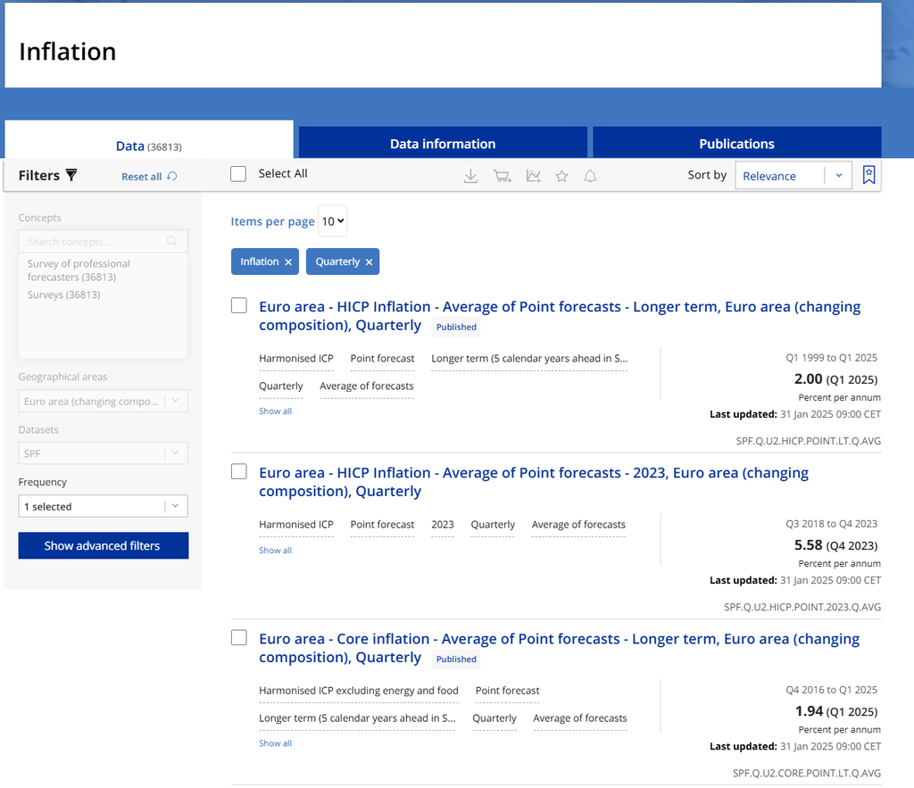

If data refers to a country, the reference is included on the third position of the name. In addition, if the data are unadjusted for seasons, the key shows N while adjustedd data show S. For instance, the monthly unemployment rate for 15-74 aged in Austria in Figure 6.4 show a couple of series:

Figure 6.4: Unemployment rate Austria, monthly

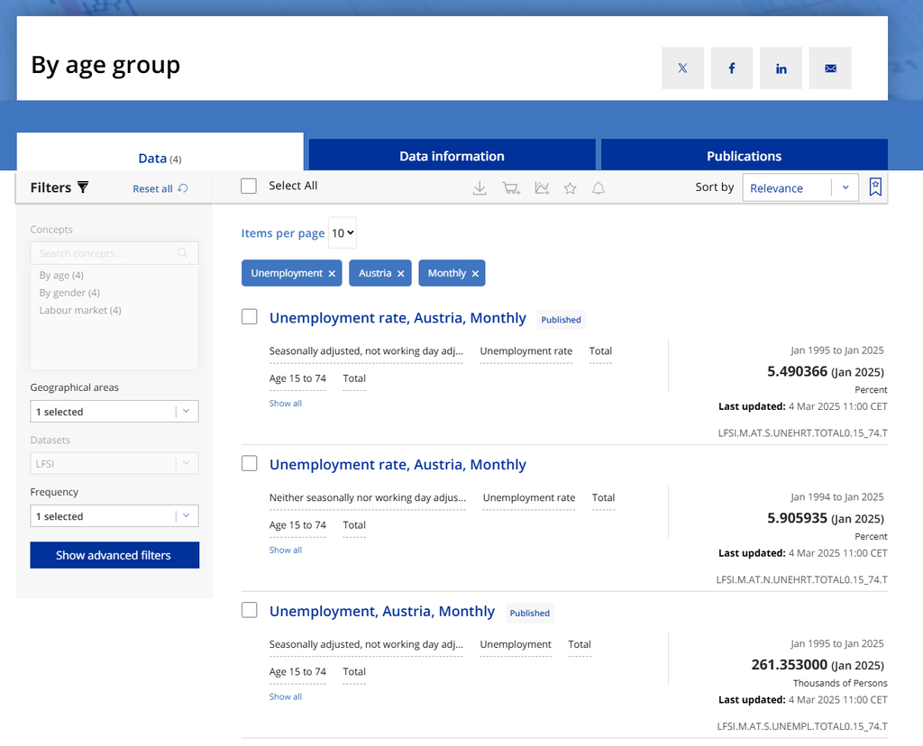

The `filter` arguments allows you to include a `startPeriod`and `endPeriod` where periods are included as YYYY for annual data, YYYY-S[1-2] for semi-annual data (YYYY-S1), YYYY-Q[1-4] for quarterly data, YYYY-MM for monthly data, YYYY-W[01-53] for weekly data and YYYY-MM-DD for daily data. To retrieve data updated since a certain point in time, you can use `filter = list(updataAfter = YYYY-MM-DDTHH:MM:SS+01:00)`. With `filter = list(firstNObservations = x)` or `filter = list(lastNObservations = x)` you reduce the data to the first x or last x observations for each series.

Let’s retrieve the data for the USD/EUR exchange rate since the start of 2025. To do so, we first set the key and the filters in a separate object. We then use `get_data(key, filter)` to import the data:

```r
key <- "EXR.D.USD.EUR.SP00.A"
filters <- list(startPeriod = "2025-01-01")

usdeur <- ecb::get_data(key, filters)
```

The API returns a tibble which includes data on the series (e.g. frequency, currency, …) as well as the “obstime” and “obsvalue”. The first is the date/time of the observation; the second the exchange rate. With respect to the data/time, the tibble shows it as a character:

```r
class(usdeur$obstime)
```

```
[1] "character"
```

To change this to data/time, you can use the one the the date or date/time functions we covered during the lectures on dates and times. For instance

```r
usdeur$obstime <- as.Date(usdeur$obstime)
```

In addition, you probably don’t need the columns on frequency, the currency in the denominator (which is the Euro) nor the exchange rate type of suffix. If you need reminders, you can include these in the name of the tibble. For isntance,

```r
usdeur_spot_d <- usdeur[c("currency", "obstime", "obsvalue")]
```

reduces the data to 3 columns: the currency (USD), the time and the value.

What if you need more series. There are a couple of ways to add multiple series. The first adds them in the key using `+`. Suppose for instance that, in addition to the USD exchange rate, you also need the GBP. Here, the series is EXR.D.GDP.EUR.SP00.A. Using this observation, you can add the include `GBP+USD` in your series key:

```r
key <- "EXR.D.GBP+USD.EUR.SP00.A"
```

You can now use the `get_data()` function to import the data (we will use the same period):

```r
key <- "EXR.D.GBP+USD.EUR.SP00.A"
filters <- list(startPeriod = "2025-01-01")

gbpusdeur <- ecb::get_data(key, filters)
```

```r
countrycode <- c("AT", "BE", "BG", "HR", "CY", "CZ", "DK", "EE", "FI", "FR", "GR", "HU", "IE", "IT", "LV", "LT", "LU", "MT", "NL", "PL", "PT", "RO", "SK", "SL", "ES", "SE")
```

```r
countrycode <- paste(countrycode, collapse = "+")
countrycode
```

```
[1] "AT+BE+BG+HR+CY+CZ+DK+EE+FI+FR+GR+HU+IE+IT+LV+LT+LU+MT+NL+PL+PT+RO+SK+SL+ES+SE"
```

We can now use `paste0` to generate the `hicpkey`:

```r
hicpkey <- paste0("ICP.M.", paste(countrycode, collapse = "+"), ".N.XEF000.4.ANR")
hicpkey
```

```
[1] "ICP.M.AT+BE+BG+HR+CY+CZ+DK+EE+FI+FR+GR+HU+IE+IT+LV+LT+LU+MT+NL+PL+PT+RO+SK+SL+ES+SE.N.XEF000.4.ANR"
```

Using this key, we can use import all data for the last 12 months

```r
filter <- list(lastNObservations = 12)
core_hicp <- get_data(hicpkey, filter)
```

The dataset `core_hicp` includes 300 observations for 8 variables. You can now change change the time of `obstime` and remove variables that you don’t need.

#### 6.3.2.3 Global economic institutions: World bank, IMF, …

Recall from ?sec-examples that we already use the {wbstats} to download data on life expectancy at birth. The package interacts with the World bank’s data service. Let’s load {wbstats} in memory

```r
library(wbstats)
```

In ?sec-examples, the keys were given

```r
my_indicators <- c(
  life_exp = "SP.DYN.LE00.IN",
  gdp_capita = "NY.GDP.PCAP.CD",
  pop = "SP.POP.TOTL"
)
```

and you could use them in the {wbstats} call:

```r
life_df <- wb_data(my_indicators, start_date = 1960, end_date = 2022)
```

How do you find these key’s? Here, there are two options. First, as you did with the ECB’s data, you can do to the data pages of the [World Bank](https://data.worldbank.org/) and search for the indicators. For instance, if you search for life expectancy at birth, you’ll find the page in Figure 6.5. You can find the code in the URL of the page as well as in the details on the data: “SP.DYN.LE00.IN”.

Figure 6.5: Life expectancy at birth, World Bank

[figure not shown]

The second way to search the data is to use the {wbstats} `wb_search()` function. The package includes the series that are available in the `wb_cachelist`

```r
str(wb_cachelist, max.level = 1)
```

```
List of 8
 $ countries    : tibble [297 × 18] (S3: tbl_df/tbl/data.frame)
 $ indicators   : tibble [16,643 × 8] (S3: tbl_df/tbl/data.frame)
 $ sources      : tibble [62 × 9] (S3: tbl_df/tbl/data.frame)
 $ topics       : tibble [21 × 3] (S3: tbl_df/tbl/data.frame)
 $ regions      : tibble [42 × 4] (S3: tbl_df/tbl/data.frame)
 $ income_levels: tibble [7 × 3] (S3: tbl_df/tbl/data.frame)
 $ lending_types: tibble [4 × 3] (S3: tbl_df/tbl/data.frame)
 $ languages    : tibble [23 × 3] (S3: tbl_df/tbl/data.frame)
```

It is good idea to update the data in list. Sometimes, the World Bank changes the data it collects. To do so you can create a new cachelist using

```r
new_cashlist <- wb_cache()
```

You can now use `wb_search(pattern, fields, extra, cache, ignore.case = TRUE)`. With a new `cache`, you include the `new_cache` in that argument. In that way, you are sure that you have the most recent data.

Let’s search for “life expectancy”:

```r
life_search <- wb_search(pattern = "life expectancy", cache = new_cashlist)
```

`wb_search` returns a tibble with 7 observations. In other words, there are 7 indicators that match this pattern. Inspecting these observations, you see the indicator we need is “life expectancy at birth, total”:

```r
life_search <- wb_search(pattern = "life expectancy at birth, total", cache = new_cashlist)
```

We can now use this results for find the indicator:

```r
life_search$indicator_id
```

```
[1] "SP.DYN.LE00.IN"
```

We can find the other variables in a similar way:

```r
gdp_search <- wb_search(pattern = "gdp per capita \\(constant 2015", cache = new_cashlist)
```

The indicator for per capita GDP is

```r
gdp_search$indicator_id
```

```
[1] "NY.GDP.PCAP.KD"
```

```r
pop_search <- wb_search(pattern = "^population, total",
                        fields = c("indicator"), cache = new_cashlist)
```

With the third variable key, we can now build the import function:

```r
my_indicators <- c(
  life_exp = life_search$indicator_id,
  gdp_capita = gdp_search$indicator_id,
  pop = pop_search$indicator_id
)
```

and use the `wb_data` function to import the data:

```r
dataset <- wb_data(my_indicators,
                   country = "countries_only",
                   start_date = 2000,
                   end_date = 2020)
```

As you can see, this function also includes the option to limit the search to one for more countries. To do so, you list the countries using their ISO2 or ISO3 code. As an alternative you can select country groups by e.g. income_level of region. To see country codes or groups, you can use {wbstats}

```r
str(wb_countries())
```

```
tibble [296 × 18] (S3: tbl_df/tbl/data.frame)
 $ iso3c             : chr [1:296] "ABW" "AFE" "AFG" "AFR" ...
 $ iso2c             : chr [1:296] "AW" "ZH" "AF" "A9" ...
 $ country           : chr [1:296] "Aruba" "Africa Eastern and Southern" "Afghanistan" "Africa" ...
 $ capital_city      : chr [1:296] "Oranjestad" NA "Kabul" NA ...
 $ longitude         : num [1:296] -70 NA 69.2 NA NA ...
 $ latitude          : num [1:296] 12.5 NA 34.5 NA NA ...
 $ region_iso3c      : chr [1:296] "LCN" NA "MEA" NA ...
 $ region_iso2c      : chr [1:296] "ZJ" NA "ZQ" NA ...
 $ region            : chr [1:296] "Latin America & Caribbean" "Aggregates" "Middle East, North Africa, Afghanistan & Pakistan" "Aggregates" ...
 $ admin_region_iso3c: chr [1:296] NA NA "MNA" NA ...
 $ admin_region_iso2c: chr [1:296] NA NA "XQ" NA ...
 $ admin_region      : chr [1:296] NA NA "Middle East, North Africa, Afghanistan & Pakistan (excluding high income)" NA ...
 $ income_level_iso3c: chr [1:296] "HIC" NA "LIC" NA ...
 $ income_level_iso2c: chr [1:296] "XD" NA "XM" NA ...
 $ income_level      : chr [1:296] "High income" "Aggregates" "Low income" "Aggregates" ...
 $ lending_type_iso3c: chr [1:296] "LNX" NA "IDX" NA ...
 $ lending_type_iso2c: chr [1:296] "XX" NA "XI" NA ...
 $ lending_type      : chr [1:296] "Not classified" "Aggregates" "IDA" "Aggregates" ...
```

For instance, reducing the country dataset to countries in “Low income” categories:

```r
wbcountries <- wb_countries()
countries <- wbcountries[wbcountries$income_level == "Low income", ]$iso3c
dataset2 <- wb_data(my_indicators,
        country = countries,
        start_date = 2015,
        end_date = 2018)
```

For the International Monetary Fund, {imfr} allows you to retrieve data from one of the IMF’s databases. The function `imf_data()` in that package allows you to specify the database, the indicator, the country, frequency and both the start and end date.

#### 6.3.2.4 DBnomics R client

The [DBnomics](https://db.nomics.world/) R client allows you to access many data series, including those from the World Bank or the European Central Bank, European Commission’s AMECO database, the Bank for International Settlements (BIS), Organisation for Economic Cooperation and Development (OECD), International Labour Organisation (ILO), Eurostat, World Trade Organisation (WTO), … . Data is available in `csv`, `xlsx`, `html` and `json` format.

```r
install.packages("rdbnomics")
```

```r
library(rdbnomics)
```

Let’s see how you can use {rdbnomics} to get data from AMECO. Recall that the AMECO dataset includes a series identifyer. For instance, the population data for Germany, included in AMECO1 files is DEU.1.0.0.0.NPDT. Using {rdbnomics} `rdb()` function, you can import that series using:

```r
datapop <- rdb(ids = "AMECO/NPTD/DEU.1.0.0.0.NPTD")
```

where “AMECO/NPTD” refers to the source, AMECO, and the variable, total population. This function returns a data table and includes all data as all as the name of the variable, the frequency, the period, the provider (AMECO), … .

```r
str(datapop)
```

```
Classes 'data.table' and 'data.frame':  68 obs. of  17 variables:
 $ @frequency     : chr  "annual" "annual" "annual" "annual" ...
 $ Country        : chr  "Germany" "Germany" "Germany" "Germany" ...
 $ dataset_code   : chr  "NPTD" "NPTD" "NPTD" "NPTD" ...
 $ dataset_name   : chr  "Total population (National accounts)" "Total population (National accounts)" "Total population (National accounts)" "Total population (National accounts)" ...
 $ freq           : chr  "a" "a" "a" "a" ...
 $ Frequency      : chr  "Annually" "Annually" "Annually" "Annually" ...
 $ geo            : chr  "deu" "deu" "deu" "deu" ...
 $ indexed_at     : POSIXct, format: "2025-11-18 01:13:10" "2025-11-18 01:13:10" ...
 $ original_period: chr  "1960" "1961" "1962" "1963" ...
 $ original_value : chr  "72777.68" "73340.13" "73987.95" "74676.17" ...
 $ period         : Date, format: "1960-01-01" "1961-01-01" ...
 $ provider_code  : chr  "AMECO" "AMECO" "AMECO" "AMECO" ...
 $ series_code    : chr  "DEU.1.0.0.0.NPTD" "DEU.1.0.0.0.NPTD" "DEU.1.0.0.0.NPTD" "DEU.1.0.0.0.NPTD" ...
 $ series_name    : chr  "Annually – 1000 persons – Germany" "Annually – 1000 persons – Germany" "Annually – 1000 persons – Germany" "Annually – 1000 persons – Germany" ...
 $ unit           : chr  "1000-persons" "1000-persons" "1000-persons" "1000-persons" ...
 $ Unit           : chr  "1000 persons" "1000 persons" "1000 persons" "1000 persons" ...
 $ value          : num  72778 73340 73988 74676 75280 ...
 - attr(*, ".internal.selfref")=<externalptr>
```

It is now sufficient to select the columns with the data you need.

If you want more series from the same or another provider, you can include them after the `ids =` argument in a vector, e.g. c(“AMECO/NPDT/DEU.1.0.0.0.NPDT”, “AMECO/NPDT/DNK.1.0.0.0.NPDT”). In these the second series if from another provider, you add the reference to that series from that provider.

As an alternative, `rdb` also allows to build a request using a easier approach. In this function call, you first specify the source (AMECO), the variable (unemployment or ZUTN) and then a list with countries as dimensions:

```r
dataunemp <- rdb("AMECO", "ZUTN", dimensions = list(geo = c("deu", "dnk")))
```

Other examples are available [online](https://cran.r-project.org/web/packages/rdbnomics/vignettes/rdbnomics.html#1_DBnomics:_the_world%E2%80%99s_economic_database).

#### 6.3.2.5 Statistical offices: EUROSTAT

Eurostat is statistical agency of the European Union. As most statistical agencies in the world do, Eurostats makes its huge collection of data available on the web. Here, the data is not limited to economic or financial data, but includes data on e.g. poverty, environmental pollution, migration, … . In “[Using Eurostat with R](http://stavrakoudis.econ.uoi.gr/r-eurostat/index.html)” you will find a very good overview of how you can use R to retrieve Eurostat data. For access and import Eurostat data, you can use the package {eurostat} (Lahti et al. (2023)). Here, I will only include the two main functions of this package: `search_eurostat` and `get_eurostat`.

To install, you can run

```r
install.packages("eurostat")
```

and load in memory

```r
library("eurostat")
```

The statistics that are available on Eurostat can be found on its data portal. The function `search_eurostat()` allows you to search the database. For instance, to see which datasets Eurostat collects with respect to “high-speed internet coverage”, you can use its [data portal](https://ec.europa.eu/eurostat). Here, you will also find the keys you need to retrieve the data via the {eurostat} package. For instance, the key for the data on “population by educational attainment, level, sex and age” is edat_lfse_9903. As an alternative, you can use the `search_eurostat()` function included in the {eurostat} package.

```r
search <- search_eurostat(pattern = "Population by sex, age and educational attainment level")
```

The function returns 6 values. We can now store these values in a key. The first two observations show the series we want. The first show the population in 1000’s and the second in percent. If you need the percentage of the population, you can save this code in an object e.g. `key_eurostat`:

```r
key_eurostat <- search$code
```

To import the data, you can use `get_eurostat()`

```r
data_eurostat <- get_eurostat(id = key_eurostat)
```

```
indexed 0B in  0s, 0B/s
indexed 2.15GB in  0s, 2.15GB/s
```

```
Table cens_hnelev cached at C:\Users\u0063587\AppData\Local\Temp\Rtmps5UZcO/eurostat/a18947c7821627c95bab61fe1ab09104.rds
```

In this dataset, includes all observations for all EU countries and is also cached in an `rds` file. Here you retrieved all data available in for that series. To import only data for since 1990 and only for Denmark and Germany, you can add this constraint to the `filter` argument using a list of filter

```r
data_eurostat <- get_eurostat(id = key_eurostat,
                              filters = list(geo = c("DK", "DE"),
                                            sinceTimePeriod = 1990)
                              )
```

```
Table cens_hnelev cached at C:\Users\u0063587\AppData\Local\Temp\Rtmps5UZcO/eurostat/416a40e50a0d703c81735889eeb3cc90.rds
```

**TipDigging deeper: Data on the web: webscraping**

{rvest} H. Wickham (2024) is a package that allows you to collect data by scraping websites. API are made available by those who own a website and, in doing so agree to share the data. Webscraping is different: you retrieve data without the explicit consent of the owner of the web page. To scrape data from the web, you need some knowledge of html of css selectors. If you need to use {rvest} to collect data, I refer to [chapter 24](https://r4ds.hadley.nz/webscraping.html) in Wickham Hadley, Cetinkaya-Rundel, and Grolemund (2023) and [this](https://statsandr.com/blog/web-scraping-in-r/#web-scraping-vs.-apis) post on the statsandr blog.

### 6.3.3 Databases

Here we didn’t cover databases. A database stores data in tables. You can think of tables as a data frame: the table stores variables for observations. Usually, these data bases are stored on a server. If they are large, downloading them in memory - in other words, creating a dataframe after importing them - is usually not possible. You connect to a database and use SQL (structured query language) to select variables, and observations.

In R, the {DBI} package allows you to connect to a database and retrieve data. In Chapter 8, well use {dplyr}, the package {dbplyr} allows you to use the familiar {dplyr} syntax to select and filter data in a database as it “translates’ {dplyr} verbs in SQL. To read more on R and databases, I refer you to [chapter 21](https://r4ds.hadley.nz/databases.html) of Wickham Hadley, Cetinkaya-Rundel, and Grolemund (2023).

Barrett, Tyson, Matt Dowle, Arun Srinivasan, Jan Gorecki, Michael Chirico, Toby Hocking, Benjamin Schwendinger, and Ivan Krylov. 2025. *Data.table: Extension of ‘Data.frame‘*. https://r-datatable.com.

Bryan, Jennifer. 2023. *Googlesheets4: Access Google Sheets Using the Sheets API V4*.

D’Agostino McGowan, Lucy, and Jennifer Bryan. 2023. *Googledrive: An Interface to Google Drive*.

Lahti, Leo, Janne Huovari, Markus Kainu, Przemyslaw Biecek, Diego Hernangomez, Daniel Antal, and Pyry Kantanen. 2023. “Eurostat: Tools for Eurostat Open Data.” Computer software. https://github.com/rOpenGov/eurostat.

Ooms, Jeroen. 2014. “The Jsonlite Package: A Practical and Consistent Mapping Between JSON Data and r Objects.” *arXiv:1403.2805 [Stat.CO]*. https://arxiv.org/abs/1403.2805.

Persson, Eric. 2023. *Ecb: Programmatic Access to the European Central Bank’s Statistical Data Warehouse*. https://CRAN.R-project.org/package=ecb.

Wickham, Hadley. 2023. *Httr: Tools for Working with URLs and HTTP*.

———. 2024. *Rvest: Easily Harvest (Scrape) Web Pages*. https://rvest.tidyverse.org/.

———. 2025. *Httr2: Perform HTTP Requests and Process the Responses*. https://httr2.r-lib.org.

Wickham, Hadley, and Jennifer Bryan. 2023. *Readxl: Read Excel Files*.

Wickham, Hadley, Jennifer Bryan, Malcolm Barrett, and Andy Teucher. 2024. *Usethis: Automate Package and Project Setup*. https://usethis.r-lib.org.

Wickham, Hadley, Cetinkaya-Rundel Mine, and Garrett Grolemund. 2023. *R for Data Science: Import, Tidy, Transform, Visualize, and Model Data (2nd Edition)*. Sebastopol, CA: O’Reilly Media.

Wickham, Hadley, Jim Hester, and Jennifer Bryan. 2024. *Readr: Read Rectangular Text Data*. https://readr.tidyverse.org.

Wickham, Hadley, Jim Hester, and Jeroen Ooms. 2025. *Xml2: Parse XML*. https://xml2.r-lib.org.

Wickham, Hadley, Evan Miller, and Danny Smith. 2023. *Haven: Import and Export ’SPSS’, ’Stata’ and ’SAS’ Files*. https://haven.tidyverse.org.